# Tarea Text Mining

raulvila

23/6/2020

## Introduccion y establecimiento de credenciales.

El presente trabajo tiene por objetivo analizar los twitts de los dos candidatos aspirantes a la casa blanca en Estados Unidos. Como principal insumo de trabajo fue utilizado el material visto en clase, concretamente, el documento “Text_Mining_5.Rmd”

Primeramente determino el directorio de trabajo:

```r
setwd('C:/Users/Usuario/Desktop/MASTER/text_mining')
```

Previo al analisis exploratorio instalare algunos paquetes que seran necesario:

```r
# install.packages("C:/Users/Usuario/Desktop/MASTER/text_mining/TextMining/Rstem_0.4-1.tar.gz", repos = NULL, type = "source")
# install.packages("C:/Users/Usuario/Desktop/MASTER/text_mining/TextMining/sentiment_0.2.tar.gz", repos = NULL, type = "source")
require(sentiment)
#ls("package:sentiment")
#install.packages("tm")
#install.packages("wordcloud")
#install.packages("vctrs")
#install.packages("twitteR")
```

Acto seguido llamo a los paquetes que seran necesarios en el analisis.

```r
library(vctrs)
library(Rstem)
#library(twitteR)
library(rtweet)
library(wordcloud)
library(RColorBrewer)
library(plyr)
library(ggplot2)
library(sentiment)
library(gridExtra)
library(wordcloud)
library(igraph)
library(graphTweets)
library(tm)
```

Me he dado de alta como desarrollador en twitter, donde accedi a las API para extraer los twitts de los candidatos.

api_key <- “xxxzzzzyyy” api_secret <- “xxxzzzzyyy” access_token <- “xxxzzzzyyy” access_token_secret <- “xxxzzzzyyy” twitter_app <- “raulvila21”

```r
# Accedemos a Titter a través de los datos del token
create_token(
  app             = 'raulvila21',
  consumer_key    = 'tVM4NYii3Nt2CCHvz4QPvO83g',
  consumer_secret = 'bLIibxFOukqpgRsG6o1yUJrsMB1UQuAtQbIm6QMpEHB4ROlTJx',
  access_token    = '173589802-5GWM3pfIlpES9KTJJRW7zoNDrjcRAL6TBGSsoT2V',
  access_secret   = 'f3tWDAnU3e0pcHVPf3jFm8I3PwTD9fk1gmGnv1Bo75ICz')
```

```
## <Token>
## <oauth_endpoint>
##  request:   https://api.twitter.com/oauth/request_token
##  authorize: https://api.twitter.com/oauth/authenticate
##  access:    https://api.twitter.com/oauth/access_token
## <oauth_app> raulvila21
##   key:    tVM4NYii3Nt2CCHvz4QPvO83g
##   secret: <hidden>
## <credentials> oauth_token, oauth_token_secret
## ---
```

## Recopilar la base de datos.

Realizo una peticion de twitts, para posteriormente realizar una comparacion segun un analisis de sentimiento entre los candidatos americanos. Al momento de escribir estas lineas EEUU se encuentra en campania electoral, mientras sucede un fuerte movimiento racial, producto del asesinato de George Floyd en manos del cuerpo de policia de Mineápolis.

Tal como lo vimos en clase, la librería **rtweet** nos ofrece algunas funciones para sacar información general de Twitter, como

```r
# Los emojis
emojis
```

```
## # A tibble: 2,623 x 2
##    code         description
##    <chr>        <chr>
##  1 "\U0001f600" grinning face
##  2 "\U0001f601" beaming face with smiling eyes
##  3 "\U0001f602" face with tears of joy
##  4 "\U0001f923" rolling on the floor laughing
##  5 "\U0001f603" grinning face with big eyes
##  6 "\U0001f604" grinning face with smiling eyes
##  7 "\U0001f605" grinning face with sweat
##  8 "\U0001f606" grinning squinting face
##  9 "\U0001f609" winking face
## 10 "\U0001f60a" smiling face with smiling eyes
## # ... with 2,613 more rows
```

Los lenguajes aceptados en Twitter

```r
langs
```

```
## # A tibble: 486 x 5
##    bibliographic terminologic alpha english               french
##    <chr>         <chr>        <chr> <chr>                 <chr>
##  1 aar           <NA>         aa    Afar                  afar
##  2 abk           <NA>         ab    Abkhazian             abkhaze
##  3 ace           <NA>         <NA>  Achinese              aceh
##  4 ach           <NA>         <NA>  Acoli                 acoli
##  5 ada           <NA>         <NA>  Adangme               adangme
##  6 ady           <NA>         <NA>  Adyghe; Adygei        adyghé
##  7 afa           <NA>         <NA>  Afro-Asiatic languag~ afro-asiatiques, lang~
##  8 afh           <NA>         <NA>  Afrihili              afrihili
##  9 afr           <NA>         af    Afrikaans             afrikaans
## 10 ain           <NA>         <NA>  Ainu                  aïnou
## # ... with 476 more rows
```

Ya me he descargado los twitts y los he guardado en el directorio de trabajo, por lo que unicamente los vuelvo a cargar.

```r
#dt_tweets <- search_tweets("realDonaldTrump", n = 18000, include_rts = FALSE)
```

```r
#save(dt_tweets, file = './dt_tweets_2020-06-08_DonalTrump.RData')
```

Primeramente analizare los de Trump.

```r
load('./dt_tweets_2020-06-08_DonalTrump.RData')
```

```r
dim(dt_tweets)
```

```
## [1] 17980    90
```

Procedo a realizar una limpieza de los Twitts para poder analizarlos.

Sacamos el texto:

```r
#rc_txt <- sapply(rc_tweets, function(x) x$getText())
dt_txt <- dt_tweets$text
head(dt_txt, 10)
```

```
##  [1] "@realDonaldTrump https://t.co/ZaBGwfdwyn"
##  [2] "@JoVotes45 @realDonaldTrump These people are animals. Period."
##  [3] "@sxdoc @realDonaldTrump Yes!!"
##  [4] "@realDonaldTrump BLAH BLAH BLAH !!!! GROW UP ORANGE BOY"
##  [5] "@Utopiancrane @nups_lostsoul @realDonaldTrump @Nooffence_7 @Wassup_Shant https://t.co/EOBJSowEzA"
##  [6] "@Utopiancrane @nups_lostsoul @realDonaldTrump @Nooffence_7 @Wassup_Shant https://t.co/W7sIiUQRiO"
##  [7] "@Nottoda59737847 @JRehling @realDonaldTrump Which is it? You said “every death” is counted as Covid and then use annual deaths that are 20x as many as the “counted” Covid deaths. If “every death” was counted as Covid wouldn’t there be way more deaths?"
##  [8] "@dschell6 @Antonio11637899 @DavidJHarrisJr @RyanAFournier @realDonaldTrump But it's whatever. Again go ahead and keep telling everybody they used tear gas."
##  [9] "@dschell6 @Antonio11637899 @DavidJHarrisJr @RyanAFournier @realDonaldTrump Use common sense secret service isn't gonna send trump down a walkway with tear gas in the air for one. And you keep quoting his photo op and walk of shame. Keep spreading that negativity and hate the media is lookin…
## [10] "@dschell6 @Antonio11637899 @DavidJHarrisJr @RyanAFournier @realDonaldTrump The park police does not work for trump. They state they cleared them out because the protesters was climbing on a structure that was burned the night before &amp; that people in the crowd was throwing bottles and th…
```

Los siguientes pasos seran realizar la limpieza de los twitts, tal como quitar los retweets, html links, puntuacion, la palabra amp, caracteres no alfanumericos, tco, quitamos NAs, quitamos emoticones, quitamos NAs, pasamos a minusculas, Espacios, tabuladores, etc de tal forma de llegar a un texto “Limpio”

Quito los Retweets

```r
dt_txt <- gsub("(RT|via)((?:\\b\\W*@\\w+)+)", "", dt_txt)
head(dt_txt, 10)
```

```
##  [1] "@realDonaldTrump https://t.co/ZaBGwfdwyn"
##  [2] "@JoVotes45 @realDonaldTrump These people are animals. Period."
##  [3] "@sxdoc @realDonaldTrump Yes!!"
##  [4] "@realDonaldTrump BLAH BLAH BLAH !!!! GROW UP ORANGE BOY"
##  [5] "@Utopiancrane @nups_lostsoul @realDonaldTrump @Nooffence_7 @Wassup_Shant https://t.co/EOBJSowEzA"
##  [6] "@Utopiancrane @nups_lostsoul @realDonaldTrump @Nooffence_7 @Wassup_Shant https://t.co/W7sIiUQRiO"
##  [7] "@Nottoda59737847 @JRehling @realDonaldTrump Which is it? You said “every death” is counted as Covid and then use annual deaths that are 20x as many as the “counted” Covid deaths. If “every death” was counted as Covid wouldn’t there be way more deaths?"
##  [8] "@dschell6 @Antonio11637899 @DavidJHarrisJr @RyanAFournier @realDonaldTrump But it's whatever. Again go ahead and keep telling everybody they used tear gas."
##  [9] "@dschell6 @Antonio11637899 @DavidJHarrisJr @RyanAFournier @realDonaldTrump Use common sense secret service isn't gonna send trump down a walkway with tear gas in the air for one. And you keep quoting his photo op and walk of shame. Keep spreading that negativity and hate the media is lookin…
## [10] "@dschell6 @Antonio11637899 @DavidJHarrisJr @RyanAFournier @realDonaldTrump The park police does not work for trump. They state they cleared them out because the protesters was climbing on a structure that was burned the night before &amp; that people in the crowd was throwing bottles and th…
```

Quito los html Links.

```r
dt_txt <-  gsub("\\bhttp[a-zA-Z0-9]*\\b", "", dt_txt)
head(dt_txt, 10)
```

```
##  [1] "@realDonaldTrump ://t.co/ZaBGwfdwyn"
##  [2] "@JoVotes45 @realDonaldTrump These people are animals. Period."
##  [3] "@sxdoc @realDonaldTrump Yes!!"
##  [4] "@realDonaldTrump BLAH BLAH BLAH !!!! GROW UP ORANGE BOY"
##  [5] "@Utopiancrane @nups_lostsoul @realDonaldTrump @Nooffence_7 @Wassup_Shant ://t.co/EOBJSowEzA"
##  [6] "@Utopiancrane @nups_lostsoul @realDonaldTrump @Nooffence_7 @Wassup_Shant ://t.co/W7sIiUQRiO"
##  [7] "@Nottoda59737847 @JRehling @realDonaldTrump Which is it? You said “every death” is counted as Covid and then use annual deaths that are 20x as many as the “counted” Covid deaths. If “every death” was counted as Covid wouldn’t there be way more deaths?"
##  [8] "@dschell6 @Antonio11637899 @DavidJHarrisJr @RyanAFournier @realDonaldTrump But it's whatever. Again go ahead and keep telling everybody they used tear gas."
##  [9] "@dschell6 @Antonio11637899 @DavidJHarrisJr @RyanAFournier @realDonaldTrump Use common sense secret service isn't gonna send trump down a walkway with tear gas in the air for one. And you keep quoting his photo op and walk of shame. Keep spreading that negativity and hate the media is lookin…
## [10] "@dschell6 @Antonio11637899 @DavidJHarrisJr @RyanAFournier @realDonaldTrump The park police does not work for trump. They state they cleared them out because the protesters was climbing on a structure that was burned the night before &amp; that people in the crowd was throwing bottles and th…
```

Puntuación

```r
dt_txt <- gsub("[[:punct:]]", "", dt_txt)
head(dt_txt, 10)
```

```
##  [1] "realDonaldTrump tcoZaBGwfdwyn"
##  [2] "JoVotes45 realDonaldTrump These people are animals Period"
##  [3] "sxdoc realDonaldTrump Yes"
##  [4] "realDonaldTrump BLAH BLAH BLAH  GROW UP ORANGE BOY"
##  [5] "Utopiancrane nupslostsoul realDonaldTrump Nooffence7 WassupShant tcoEOBJSowEzA"
##  [6] "Utopiancrane nupslostsoul realDonaldTrump Nooffence7 WassupShant tcoW7sIiUQRiO"
##  [7] "Nottoda59737847 JRehling realDonaldTrump Which is it You said “every death” is counted as Covid and then use annual deaths that are 20x as many as the “counted” Covid deaths If “every death” was counted as Covid wouldn’t there be way more deaths"
##  [8] "dschell6 Antonio11637899 DavidJHarrisJr RyanAFournier realDonaldTrump But its whatever Again go ahead and keep telling everybody they used tear gas"
##  [9] "dschell6 Antonio11637899 DavidJHarrisJr RyanAFournier realDonaldTrump Use common sense secret service isnt gonna send trump down a walkway with tear gas in the air for one And you keep quoting his photo op and walk of shame Keep spreading that negativity and hate the media is looking for"
## [10] "dschell6 Antonio11637899 DavidJHarrisJr RyanAFournier realDonaldTrump The park police does not work for trump They state they cleared them out because the protesters was climbing on a structure that was burned the night before amp that people in the crowd was throwing bottles and things at …
```

La palabra amp

```r
dt_txt <- gsub("amp ", "", dt_txt)
head(dt_txt, 10)
```

```
##  [1] "realDonaldTrump tcoZaBGwfdwyn"
##  [2] "JoVotes45 realDonaldTrump These people are animals Period"
##  [3] "sxdoc realDonaldTrump Yes"
##  [4] "realDonaldTrump BLAH BLAH BLAH  GROW UP ORANGE BOY"
##  [5] "Utopiancrane nupslostsoul realDonaldTrump Nooffence7 WassupShant tcoEOBJSowEzA"
##  [6] "Utopiancrane nupslostsoul realDonaldTrump Nooffence7 WassupShant tcoW7sIiUQRiO"
##  [7] "Nottoda59737847 JRehling realDonaldTrump Which is it You said “every death” is counted as Covid and then use annual deaths that are 20x as many as the “counted” Covid deaths If “every death” was counted as Covid wouldn’t there be way more deaths"
##  [8] "dschell6 Antonio11637899 DavidJHarrisJr RyanAFournier realDonaldTrump But its whatever Again go ahead and keep telling everybody they used tear gas"
##  [9] "dschell6 Antonio11637899 DavidJHarrisJr RyanAFournier realDonaldTrump Use common sense secret service isnt gonna send trump down a walkway with tear gas in the air for one And you keep quoting his photo op and walk of shame Keep spreading that negativity and hate the media is looking for"
## [10] "dschell6 Antonio11637899 DavidJHarrisJr RyanAFournier realDonaldTrump The park police does not work for trump They state they cleared them out because the protesters was climbing on a structure that was burned the night before that people in the crowd was throwing bottles and things at them…
```

Caracteres no alfanuméricos

```r
dt_txt <- gsub("[^a-zA-Z0-9 ]", "", dt_txt)
head(dt_txt, 10)
```

```
##  [1] "realDonaldTrump tcoZaBGwfdwyn"
##  [2] "JoVotes45 realDonaldTrump These people are animals Period"
##  [3] "sxdoc realDonaldTrump Yes"
##  [4] "realDonaldTrump BLAH BLAH BLAH  GROW UP ORANGE BOY"
##  [5] "Utopiancrane nupslostsoul realDonaldTrump Nooffence7 WassupShant tcoEOBJSowEzA"
##  [6] "Utopiancrane nupslostsoul realDonaldTrump Nooffence7 WassupShant tcoW7sIiUQRiO"
##  [7] "Nottoda59737847 JRehling realDonaldTrump Which is it You said every death is counted as Covid and then use annual deaths that are 20x as many as the counted Covid deaths If every death was counted as Covid wouldnt there be way more deaths"
##  [8] "dschell6 Antonio11637899 DavidJHarrisJr RyanAFournier realDonaldTrump But its whatever Again go ahead and keep telling everybody they used tear gas"
##  [9] "dschell6 Antonio11637899 DavidJHarrisJr RyanAFournier realDonaldTrump Use common sense secret service isnt gonna send trump down a walkway with tear gas in the air for one And you keep quoting his photo op and walk of shame Keep spreading that negativity and hate the media is looking for"
## [10] "dschell6 Antonio11637899 DavidJHarrisJr RyanAFournier realDonaldTrump The park police does not work for trump They state they cleared them out because the protesters was climbing on a structure that was burned the night before that people in the crowd was throwing bottles and things at them…
```

tco

```r
dt_txt <-  gsub("\\btco[a-zA-Z0-9]*\\b", "", dt_txt)
head(dt_txt, 10)
```

```
##  [1] "realDonaldTrump "
##  [2] "JoVotes45 realDonaldTrump These people are animals Period"
##  [3] "sxdoc realDonaldTrump Yes"
##  [4] "realDonaldTrump BLAH BLAH BLAH  GROW UP ORANGE BOY"
##  [5] "Utopiancrane nupslostsoul realDonaldTrump Nooffence7 WassupShant "
##  [6] "Utopiancrane nupslostsoul realDonaldTrump Nooffence7 WassupShant "
##  [7] "Nottoda59737847 JRehling realDonaldTrump Which is it You said every death is counted as Covid and then use annual deaths that are 20x as many as the counted Covid deaths If every death was counted as Covid wouldnt there be way more deaths"
##  [8] "dschell6 Antonio11637899 DavidJHarrisJr RyanAFournier realDonaldTrump But its whatever Again go ahead and keep telling everybody they used tear gas"
##  [9] "dschell6 Antonio11637899 DavidJHarrisJr RyanAFournier realDonaldTrump Use common sense secret service isnt gonna send trump down a walkway with tear gas in the air for one And you keep quoting his photo op and walk of shame Keep spreading that negativity and hate the media is looking for"
## [10] "dschell6 Antonio11637899 DavidJHarrisJr RyanAFournier realDonaldTrump The park police does not work for trump They state they cleared them out because the protesters was climbing on a structure that was burned the night before that people in the crowd was throwing bottles and things at them…
```

Quitamos NAs

```r
dt_txt <- dt_txt[!is.na(dt_txt)]
head(dt_txt, 10)
```

```
##  [1] "realDonaldTrump "
##  [2] "JoVotes45 realDonaldTrump These people are animals Period"
##  [3] "sxdoc realDonaldTrump Yes"
##  [4] "realDonaldTrump BLAH BLAH BLAH  GROW UP ORANGE BOY"
##  [5] "Utopiancrane nupslostsoul realDonaldTrump Nooffence7 WassupShant "
##  [6] "Utopiancrane nupslostsoul realDonaldTrump Nooffence7 WassupShant "
##  [7] "Nottoda59737847 JRehling realDonaldTrump Which is it You said every death is counted as Covid and then use annual deaths that are 20x as many as the counted Covid deaths If every death was counted as Covid wouldnt there be way more deaths"
##  [8] "dschell6 Antonio11637899 DavidJHarrisJr RyanAFournier realDonaldTrump But its whatever Again go ahead and keep telling everybody they used tear gas"
##  [9] "dschell6 Antonio11637899 DavidJHarrisJr RyanAFournier realDonaldTrump Use common sense secret service isnt gonna send trump down a walkway with tear gas in the air for one And you keep quoting his photo op and walk of shame Keep spreading that negativity and hate the media is looking for"
## [10] "dschell6 Antonio11637899 DavidJHarrisJr RyanAFournier realDonaldTrump The park police does not work for trump They state they cleared them out because the protesters was climbing on a structure that was burned the night before that people in the crowd was throwing bottles and things at them…
```

Quitamos emoticonos

```r
dt_txt <- iconv(dt_txt, 'UTF-8', 'ASCII')
head(dt_txt, 10)
```

```
##  [1] "realDonaldTrump "
##  [2] "JoVotes45 realDonaldTrump These people are animals Period"
##  [3] "sxdoc realDonaldTrump Yes"
##  [4] "realDonaldTrump BLAH BLAH BLAH  GROW UP ORANGE BOY"
##  [5] "Utopiancrane nupslostsoul realDonaldTrump Nooffence7 WassupShant "
##  [6] "Utopiancrane nupslostsoul realDonaldTrump Nooffence7 WassupShant "
##  [7] "Nottoda59737847 JRehling realDonaldTrump Which is it You said every death is counted as Covid and then use annual deaths that are 20x as many as the counted Covid deaths If every death was counted as Covid wouldnt there be way more deaths"
##  [8] "dschell6 Antonio11637899 DavidJHarrisJr RyanAFournier realDonaldTrump But its whatever Again go ahead and keep telling everybody they used tear gas"
##  [9] "dschell6 Antonio11637899 DavidJHarrisJr RyanAFournier realDonaldTrump Use common sense secret service isnt gonna send trump down a walkway with tear gas in the air for one And you keep quoting his photo op and walk of shame Keep spreading that negativity and hate the media is looking for"
## [10] "dschell6 Antonio11637899 DavidJHarrisJr RyanAFournier realDonaldTrump The park police does not work for trump They state they cleared them out because the protesters was climbing on a structure that was burned the night before that people in the crowd was throwing bottles and things at them…
```

Pasamos a minúsculas

```r
dt_txt <- tolower(dt_txt)
head(dt_txt, 10)
```

```
##  [1] "realdonaldtrump "
##  [2] "jovotes45 realdonaldtrump these people are animals period"
##  [3] "sxdoc realdonaldtrump yes"
##  [4] "realdonaldtrump blah blah blah  grow up orange boy"
##  [5] "utopiancrane nupslostsoul realdonaldtrump nooffence7 wassupshant "
##  [6] "utopiancrane nupslostsoul realdonaldtrump nooffence7 wassupshant "
##  [7] "nottoda59737847 jrehling realdonaldtrump which is it you said every death is counted as covid and then use annual deaths that are 20x as many as the counted covid deaths if every death was counted as covid wouldnt there be way more deaths"
##  [8] "dschell6 antonio11637899 davidjharrisjr ryanafournier realdonaldtrump but its whatever again go ahead and keep telling everybody they used tear gas"
##  [9] "dschell6 antonio11637899 davidjharrisjr ryanafournier realdonaldtrump use common sense secret service isnt gonna send trump down a walkway with tear gas in the air for one and you keep quoting his photo op and walk of shame keep spreading that negativity and hate the media is looking for"
## [10] "dschell6 antonio11637899 davidjharrisjr ryanafournier realdonaldtrump the park police does not work for trump they state they cleared them out because the protesters was climbing on a structure that was burned the night before that people in the crowd was throwing bottles and things at them…
```

Espacios, tabuladores, etc

```r
dt_txt <- gsub("[ \t]{2,}", "", dt_txt)
dt_txt <- gsub("^\\s+|\\s+$", "", dt_txt)
head(dt_txt, 10)
```

```
##  [1] "realdonaldtrump"
##  [2] "jovotes45 realdonaldtrump these people are animals period"
##  [3] "sxdoc realdonaldtrump yes"
##  [4] "realdonaldtrump blah blah blahgrow up orange boy"
##  [5] "utopiancrane nupslostsoul realdonaldtrump nooffence7 wassupshant"
##  [6] "utopiancrane nupslostsoul realdonaldtrump nooffence7 wassupshant"
##  [7] "nottoda59737847 jrehling realdonaldtrump which is it you said every death is counted as covid and then use annual deaths that are 20x as many as the counted covid deaths if every death was counted as covid wouldnt there be way more deaths"
##  [8] "dschell6 antonio11637899 davidjharrisjr ryanafournier realdonaldtrump but its whatever again go ahead and keep telling everybody they used tear gas"
##  [9] "dschell6 antonio11637899 davidjharrisjr ryanafournier realdonaldtrump use common sense secret service isnt gonna send trump down a walkway with tear gas in the air for one and you keep quoting his photo op and walk of shame keep spreading that negativity and hate the media is looking for"
## [10] "dschell6 antonio11637899 davidjharrisjr ryanafournier realdonaldtrump the park police does not work for trump they state they cleared them out because the protesters was climbing on a structure that was burned the night before that people in the crowd was throwing bottles and things at them…
```

Vemos como nos ha quedado el texto. Primero el original

```r
# head(sapply(rc_tweets, function(x) x$getText()), 10)
head(dt_tweets$text, 10)
```

```
##  [1] "@realDonaldTrump https://t.co/ZaBGwfdwyn"
##  [2] "@JoVotes45 @realDonaldTrump These people are animals. Period."
##  [3] "@sxdoc @realDonaldTrump Yes!!"
##  [4] "@realDonaldTrump BLAH BLAH BLAH !!!! GROW UP ORANGE BOY"
##  [5] "@Utopiancrane @nups_lostsoul @realDonaldTrump @Nooffence_7 @Wassup_Shant https://t.co/EOBJSowEzA"
##  [6] "@Utopiancrane @nups_lostsoul @realDonaldTrump @Nooffence_7 @Wassup_Shant https://t.co/W7sIiUQRiO"
##  [7] "@Nottoda59737847 @JRehling @realDonaldTrump Which is it? You said “every death” is counted as Covid and then use annual deaths that are 20x as many as the “counted” Covid deaths. If “every death” was counted as Covid wouldn’t there be way more deaths?"
##  [8] "@dschell6 @Antonio11637899 @DavidJHarrisJr @RyanAFournier @realDonaldTrump But it's whatever. Again go ahead and keep telling everybody they used tear gas."
##  [9] "@dschell6 @Antonio11637899 @DavidJHarrisJr @RyanAFournier @realDonaldTrump Use common sense secret service isn't gonna send trump down a walkway with tear gas in the air for one. And you keep quoting his photo op and walk of shame. Keep spreading that negativity and hate the media is lookin…
## [10] "@dschell6 @Antonio11637899 @DavidJHarrisJr @RyanAFournier @realDonaldTrump The park police does not work for trump. They state they cleared them out because the protesters was climbing on a structure that was burned the night before &amp; that people in the crowd was throwing bottles and th…
```

Y el limpio

```r
head(dt_txt, 10)
```

```
##  [1] "realdonaldtrump"
##  [2] "jovotes45 realdonaldtrump these people are animals period"
##  [3] "sxdoc realdonaldtrump yes"
##  [4] "realdonaldtrump blah blah blahgrow up orange boy"
##  [5] "utopiancrane nupslostsoul realdonaldtrump nooffence7 wassupshant"
##  [6] "utopiancrane nupslostsoul realdonaldtrump nooffence7 wassupshant"
##  [7] "nottoda59737847 jrehling realdonaldtrump which is it you said every death is counted as covid and then use annual deaths that are 20x as many as the counted covid deaths if every death was counted as covid wouldnt there be way more deaths"
##  [8] "dschell6 antonio11637899 davidjharrisjr ryanafournier realdonaldtrump but its whatever again go ahead and keep telling everybody they used tear gas"
##  [9] "dschell6 antonio11637899 davidjharrisjr ryanafournier realdonaldtrump use common sense secret service isnt gonna send trump down a walkway with tear gas in the air for one and you keep quoting his photo op and walk of shame keep spreading that negativity and hate the media is looking for"
## [10] "dschell6 antonio11637899 davidjharrisjr ryanafournier realdonaldtrump the park police does not work for trump they state they cleared them out because the protesters was climbing on a structure that was burned the night before that people in the crowd was throwing bottles and things at them…
```

### Clasificar emociones

Empezamos clasificando emociones con *classify_emotion* usando un algoritmo de Bayes.```

```r
dt_class_emo <- classify_emotion(dt_txt, algorithm="bayes", prior=1.0)
```

La función nos retorna 7 columnas: anger, disgust, fear, joy, sadness, surprise y best_fit para cada fila del documento

```r
head(dt_class_emo)
```

```
##      ANGER              DISGUST            FEAR
## [1,] "1.46871776464786" "3.09234031207392" "2.06783599555953"
## [2,] "1.46871776464786" "3.09234031207392" "2.06783599555953"
## [3,] "1.46871776464786" "3.09234031207392" "2.06783599555953"
## [4,] "1.46871776464786" "3.09234031207392" "2.06783599555953"
## [5,] "1.46871776464786" "3.09234031207392" "2.06783599555953"
## [6,] "1.46871776464786" "3.09234031207392" "2.06783599555953"
##      JOY                SADNESS           SURPRISE           BEST_FIT
## [1,] "1.02547755260094" "1.7277074477352" "2.78695866252273" NA
## [2,] "1.02547755260094" "1.7277074477352" "2.78695866252273" NA
## [3,] "1.02547755260094" "1.7277074477352" "2.78695866252273" NA
## [4,] "1.02547755260094" "1.7277074477352" "2.78695866252273" NA
## [5,] "1.02547755260094" "1.7277074477352" "2.78695866252273" NA
## [6,] "1.02547755260094" "1.7277074477352" "2.78695866252273" NA
```

La que según el algoritmo encaja mejor (BEST_FIT) la guardamos

```r
# Guardamos en el objeto emotion
emotion <- dt_class_emo[, 7]

# Y lo vemos en una tabla
table(emotion, useNA = 'ifany')
```

```
## emotion
##    anger  disgust     fear      joy  sadness surprise     <NA>
##      580      200      304     2873     1019      257    12747
```

Para facilitar la clasificación, vamos a substituir los NAs por unknown

```r
emotion[is.na(emotion)] <- "unknown"
table(emotion, useNA = 'ifany')
```

```
## emotion
##    anger  disgust     fear      joy  sadness surprise  unknown
##      580      200      304     2873     1019      257    12747
```

En un gráfico

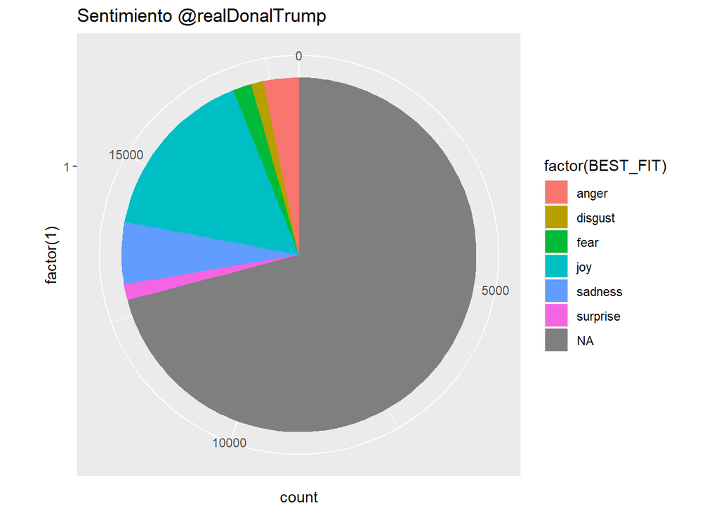

```r
pie <- ggplot(as.data.frame(dt_class_emo), aes(x = factor(1), fill = factor(BEST_FIT))) +
 geom_bar(width = 1)
pie + coord_polar(theta = "y") + labs(title = 'Sentimiento @realDonalTrump')
```

Mucho mejor con otro formato que no sea una tarta (podemos ver por qué, [aqui](https://www.elartedepresentar.com/2011/11/4-formas-de-mentir-con-graficos-de-datos-en-una-presentacion/) por ejemplo)

A modo de resumen, tal como vimos en clase, nuestro ojo no es bueno disinguiendo angulos de grafico de tortas, por lo que seria mejor evitarlos y presentarlos en otro formato como por ejemplo de barra.

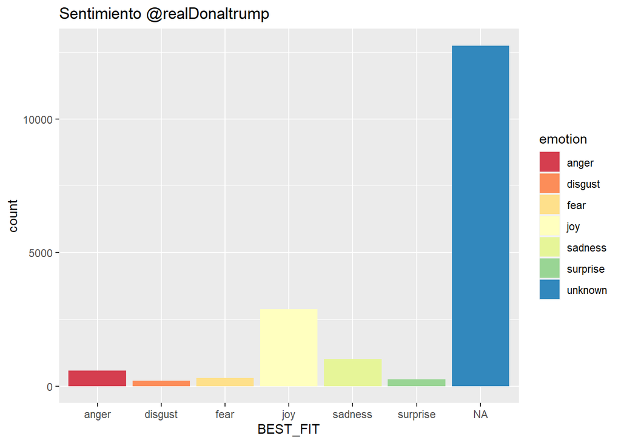

```r
g <- ggplot(as.data.frame(dt_class_emo), aes(x = BEST_FIT)) +
 geom_bar() + labs(title = 'Sentimiento @realDonaltrump') + geom_bar(aes(y=..count.., fill=emotion)) +
      scale_fill_brewer(palette="Spectral")
g
```

Ahora obtenemos la polaridad. Clasificamos el texto en cuatro categorías:

- POS: Sentimiento positivo
- NEG: Sentimiento negativo
- POS/NEG: Indefinido
- BEST_FIT: La mas probable

```r
dt_class_pol <- classify_polarity(dt_txt, algorithm="bayes")
head(dt_class_pol, 3)
```

```
##      POS                NEG                 POS/NEG            BEST_FIT
## [1,] "1.03127774142571" "0.445453222112551" "2.31512017476245" "positive"
## [2,] "1.03127774142571" "0.445453222112551" "2.31512017476245" "positive"
## [3,] "9.47547003995745" "0.445453222112551" "21.2715265477714" "positive"
```

Como antes, creamos un objeto con el resultado, en este caso la polaridad

```r
polarity <- dt_class_pol[, 4]
head(polarity)
```

```
## [1] "positive" "positive" "positive" "negative" "positive" "positive"
```

En una tabla

```r
table(polarity, useNA = 'ifany')
```

```
## polarity
## negative  neutral positive
##     5485     2621     9874
```

Recopilamos la información en un dataframe

```r
sentiment_dataframe <- data.frame(text     = dt_txt,
                                  emotion  = emotion,
                                  polarity = polarity, stringsAsFactors=FALSE)
head(sentiment_dataframe)
```

```
##                                                               text emotion
## 1                                                  realdonaldtrump unknown
## 2        jovotes45 realdonaldtrump these people are animals period unknown
## 3                                        sxdoc realdonaldtrump yes unknown
## 4                 realdonaldtrump blah blah blahgrow up orange boy unknown
## 5 utopiancrane nupslostsoul realdonaldtrump nooffence7 wassupshant unknown
## 6 utopiancrane nupslostsoul realdonaldtrump nooffence7 wassupshant unknown
##   polarity
## 1 positive
## 2 positive
## 3 positive
## 4 negative
## 5 positive
## 6 positive
```

Lo reordenamos

```r
sentiment_dataframe <- within(sentiment_dataframe, emotion <- factor(emotion, levels=names(sort(table(emotion), decreasing=TRUE))))
head(sentiment_dataframe)
```

```
##                                                               text emotion
## 1                                                  realdonaldtrump unknown
## 2        jovotes45 realdonaldtrump these people are animals period unknown
## 3                                        sxdoc realdonaldtrump yes unknown
## 4                 realdonaldtrump blah blah blahgrow up orange boy unknown
## 5 utopiancrane nupslostsoul realdonaldtrump nooffence7 wassupshant unknown
## 6 utopiancrane nupslostsoul realdonaldtrump nooffence7 wassupshant unknown
##   polarity
## 1 positive
## 2 positive
## 3 positive
## 4 negative
## 5 positive
## 6 positive
```

### Gráficos

Número de Tweets clasificados por categorías

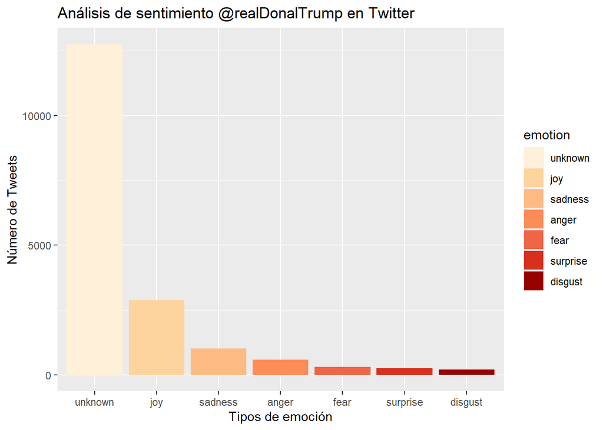

```r
ggplot(sentiment_dataframe, aes(x = emotion)) + geom_bar(aes(y = ..count.., fill = emotion)) +
      scale_fill_brewer(palette = "OrRd") +
      ggtitle("Análisis de sentimiento @realDonalTrump en Twitter") +
      theme(legend.position="right") + ylab("Número de Tweets") + xlab("Tipos de emoción")
```

Polaridad por tweets

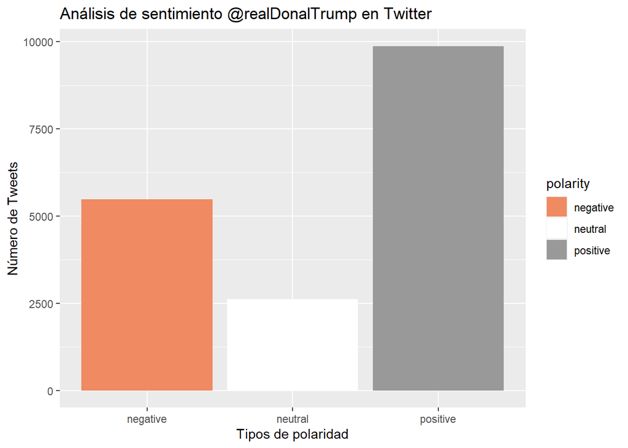

```r
ggplot(sentiment_dataframe, aes(x = polarity)) +
      geom_bar(aes(y = ..count.., fill = polarity)) +
      scale_fill_brewer(palette = "RdGy") +
      ggtitle("Análisis de sentimiento @realDonalTrump en Twitter") +
      theme(legend.position="right") + ylab("Número de Tweets") + xlab("Tipos de polaridad")
```

Separamos las palabras según las emociones

```r
dt_emos     <- levels(factor(sentiment_dataframe$emotion))
n_dt_emos   <- length(dt_emos)
dt_emo_docs <- rep("", n_dt_emos)
for (i in 1:n_dt_emos)
{
      tmp <- dt_txt[emotion == dt_emos[i]]
      dt_emo_docs[i] <- paste(tmp, collapse=" ")
}
```

Lo vemos

```r
head(dt_emos)
```

```
## [1] "unknown"  "joy"      "sadness"  "anger"    "fear"     "surprise"
```

Creamos un corpus

```r
dt_corpus <- Corpus(VectorSource(dt_txt))
inspect(dt_corpus[1:10])
```

```
## <<SimpleCorpus>>
## Metadata:  corpus specific: 1, document level (indexed): 0
## Content:  documents: 10
##
##  [1] realdonaldtrump
##  [2] jovotes45 realdonaldtrump these people are animals period
##  [3] sxdoc realdonaldtrump yes
##  [4] realdonaldtrump blah blah blahgrow up orange boy
##  [5] utopiancrane nupslostsoul realdonaldtrump nooffence7 wassupshant
##  [6] utopiancrane nupslostsoul realdonaldtrump nooffence7 wassupshant
##  [7] nottoda59737847 jrehling realdonaldtrump which is it you said every death is counted as covid and then use annual deaths that are 20x as many as the counted covid deaths if every death was counted as covid wouldnt there be way more deaths
##  [8] dschell6 antonio11637899 davidjharrisjr ryanafournier realdonaldtrump but its whatever again go ahead and keep telling everybody they used tear gas
##  [9] dschell6 antonio11637899 davidjharrisjr ryanafournier realdonaldtrump use common sense secret service isnt gonna send trump down a walkway with tear gas in the air for one and you keep quoting his photo op and walk of shame keep spreading that negativity and hate the media is looking for
## [10] dschell6 antonio11637899 davidjharrisjr ryanafournier realdonaldtrump the park police does not work for trump they state they cleared them out because the protesters was climbing on a structure that was burned the night before that people in the crowd was throwing bottles and things at them …
```

Lo podemos limpiar con *tm_map*

```r
# Pasamos a minúsculas
corpus_clean <- tm_map(dt_corpus, tolower)
# Quitamos los números
corpus_clean <- tm_map(corpus_clean, removeNumbers)
# Quitamos puntauación
corpus_clean <- tm_map(corpus_clean, removePunctuation)
# Quitamos stopwords
corpus_clean <- tm_map(corpus_clean, removeWords, stopwords())
# Quitamos espacios en blanco
corpus_clean <- tm_map(corpus_clean, stripWhitespace)
```

Un tdm (Term Document Matrix)

```r
#dt_tdm           <- TermDocumentMatrix(dt_corpus, control = list(stopwords = TRUE))
#dt_tdm           <- as.matrix(dt_tdm)
```

Un dtm (Document-Term Matrix)

```r
dt_dtm <- DocumentTermMatrix(dt_corpus, control = list(minWordLength = 1,
                                                       stopwords = TRUE))
inspect(dt_dtm)
```

```
## <<DocumentTermMatrix (documents: 17980, terms: 28702)>>
## Non-/sparse entries: 169885/515892075
## Sparsity           : 100%
## Maximal term length: 280
## Weighting          : term frequency (tf)
## Sample             :
##        Terms
## Docs    dont just know like people president realdonaldtrump trump will youre
##   10248    0    0    0    0      0         0               1     0    0     0
##   13072    0    0    0    0      0         0               1     0    0     0
##   16796    0    0    0    0      0         0               1     0    0     0
##   1815     0    0    0    0      0         0               1     0    0     0
##   1817     0    1    0    0      0         0               1     0    0     0
##   1820     0    0    0    0      0         0               1     0    0     0
##   1821     0    0    0    0      0         0               1     0    0     0
##   2738     0    0    0    0      0         0               1     0    0     0
##   6117     0    0    0    0      0         1               1     2    0     0
##   712      0    0    0    0      0         0               1     0    0     0
```

Hacemos el stem

```r
dt_corpus_stem <- tm_map(dt_corpus, stemDocument)
dt_corpus_stem <- tm_map(dt_corpus_stem, stemCompletion, dictionary = dt_corpus)
inspect(dt_corpus_stem[1:5])
```

```
## <<SimpleCorpus>>
## Metadata:  corpus specific: 1, document level (indexed): 0
## Content:  documents: 5
##
##                                              realdonaldtrump
##                                              realdonaldtrump
##        jovotes45 realdonaldtrump these peopl are anim period
##
##                                    sxdoc realdonaldtrump yes
##
##              realdonaldtrump blah blah blahgrow up orang boy
##
## utopiancran nupslostsoul realdonaldtrump nooffence7 wassupsh
##
```

Los términos mas frecuentes

```r
head(findFreqTerms(dt_dtm, lowfreq=10), 20)
```

```
##  [1] "realdonaldtrump" "people"          "period"          "yes"
##  [5] "blah"            "boy"             "orange"          "covid"
##  [9] "death"           "deaths"          "every"           "jrehling"
## [13] "many"            "said"            "use"             "way"
## [17] "wouldnt"         "ahead"           "everybody"       "gas"
```

Vamos a ver qué palabras están mas asociadas a la palabra campaign

```r
findAssocs(dt_dtm, 'campaign', 0.10)
```

```
## $campaign
##          manager             belt         identity         revolved
##             0.20             0.20             0.20             0.20
##             rust             whod              ads          finance
##             0.20             0.20             0.19             0.18
## reelectionreport      ineffective           spying
##             0.14             0.11             0.11
```

Dado el contexto del analisis también las mas relacionadas con George Floyd.

```r
findAssocs(dt_dtm, 'floyd', 0.10)
```

```
## $floyd
##                                                                                      george
##                                                                                        0.50
##                                                                                     updates
##                                                                                        0.21
##                                                                                      bailey
##                                                                                        0.20
##                                                                                    cabshare
##                                                                                        0.20
##                                                                       heretcorycibkzcrqmore
##                                                                                        0.20
##                                                                                     scammed
##                                                                                        0.20
##                                                                                         ben
##                                                                                        0.16
##                                                                                    vasthied
##                                                                                        0.16
##                                                                                       actor
##                                                                                        0.16
##                                                                                    followit
##                                                                                        0.14
##                                                                                 goodclearly
##                                                                                        0.14
##                                                                                 suggestions
##                                                                                        0.14
##                                                                       trainingimhotrump2020
##                                                                                        0.14
##                                                                                       forty
##                                                                                        0.14
##                                                                                     jitters
##                                                                                        0.14
##                                                                                     assumed
##                                                                                        0.14
##                                                                                     culprit
##                                                                                        0.14
##                                                                         policetco4p3ktyhhts
##                                                                                        0.14
##                                                                                     upended
##                                                                                        0.14
##                                                                                 securityhas
```

[output cut: 224 more lines]

```
##                                                                                        0.13
##                                                                                     blaming
##                                                                                        0.13
##                                                                                    shooting
##                                                                                        0.12
##                                                                               attorneycrump
##                                                                                        0.12
##                                                                              cedricrichmond
##                                                                                        0.12
##                                                                                    thereval
##                                                                                        0.12
##                                                                                       video
##                                                                                        0.11
##                                                                                      actors
##                                                                                        0.10
```

### Nube de palabras

Tras varios intentos con el minimo de frecuencia, para obtener una mejor nube de palabras, eleve la frecuencia minima.

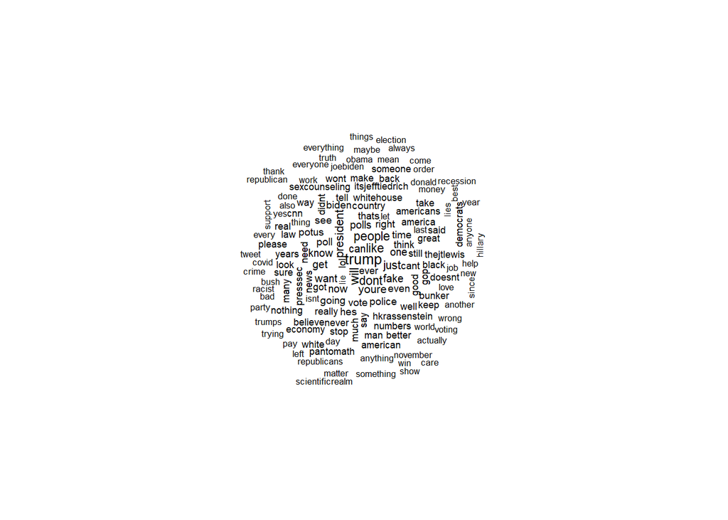

```r
wordcloud(corpus_clean, min.freq = 150, random.order = FALSE)
```

### Seguidos

```r
dt_fds <- get_friends("realDonaldTrump")
dt_fds
```

```
## # A tibble: 46 x 2
##    user            user_id
##    <chr>           <chr>
##  1 realDonaldTrump 29458079
##  2 realDonaldTrump 18166778
##  3 realDonaldTrump 208155240
##  4 realDonaldTrump 818910970567344128
##  5 realDonaldTrump 2353605901
##  6 realDonaldTrump 17685258
##  7 realDonaldTrump 818927131883356161
##  8 realDonaldTrump 22703645
##  9 realDonaldTrump 56561449
## 10 realDonaldTrump 822215673812119553
## # ... with 36 more rows
```

```r
dt_fds_data <- lookup_users(dt_fds$user_id)
dt_fds_data
```

```
## # A tibble: 46 x 90
##    user_id status_id created_at          screen_name text  source
##    <chr>   <chr>     <dttm>              <chr>       <chr> <chr>
##  1 294580~ 12732836~ 2020-06-17 15:57:37 JudgeJeani~ "ICY~ Twitt~
##  2 181667~ 12733438~ 2020-06-17 19:56:35 Jim_Jordan  "Ame~ Twitt~
##  3 208155~ 12733094~ 2020-06-17 17:40:03 MariaBarti~ "Cap~ Hoots~
##  4 818910~ 12733004~ 2020-06-17 17:04:11 VP          "htt~ Twitt~
##  5 235360~ 12733517~ 2020-06-17 20:28:11 GOPChairwo~ "One~ Sprou~
##  6 176852~ 12733583~ 2020-06-17 20:54:20 parscale    "Joe~ Twitt~
##  7 818927~ 12730822~ 2020-06-17 02:37:09 PressSec    "I w~ Twitt~
##  8 227036~ 12716163~ 2020-06-13 01:32:24 TuckerCarl~ "New~ Twitt~
##  9 565614~ 12732295~ 2020-06-17 12:22:26 JesseBWatt~ "Wat~ Twitt~
## 10 822215~ 12733648~ 2020-06-17 21:20:15 WhiteHouse  "\"I~ TheWh~
## # ... with 36 more rows, and 84 more variables: display_text_width <int>,
## #   reply_to_status_id <chr>, reply_to_user_id <chr>,
## #   reply_to_screen_name <chr>, is_quote <lgl>, is_retweet <lgl>,
## #   favorite_count <int>, retweet_count <int>, quote_count <int>,
## #   reply_count <int>, hashtags <list>, symbols <list>, urls_url <list>,
## #   urls_t.co <list>, urls_expanded_url <list>, media_url <list>,
## #   media_t.co <list>, media_expanded_url <list>, media_type <list>,
## #   ext_media_url <list>, ext_media_t.co <list>, ext_media_expanded_url <list>,
## #   ext_media_type <chr>, mentions_user_id <list>, mentions_screen_name <list>,
## #   lang <chr>, quoted_status_id <chr>, quoted_text <chr>,
## #   quoted_created_at <dttm>, quoted_source <chr>, quoted_favorite_count <int>,
## #   quoted_retweet_count <int>, quoted_user_id <chr>, quoted_screen_name <chr>,
## #   quoted_name <chr>, quoted_followers_count <int>,
## #   quoted_friends_count <int>, quoted_statuses_count <int>,
## #   quoted_location <chr>, quoted_description <chr>, quoted_verified <lgl>,
## #   retweet_status_id <chr>, retweet_text <chr>, retweet_created_at <dttm>,
## #   retweet_source <chr>, retweet_favorite_count <int>,
## #   retweet_retweet_count <int>, retweet_user_id <chr>,
## #   retweet_screen_name <chr>, retweet_name <chr>,
## #   retweet_followers_count <int>, retweet_friends_count <int>,
## #   retweet_statuses_count <int>, retweet_location <chr>,
## #   retweet_description <chr>, retweet_verified <lgl>, place_url <chr>,
## #   place_name <chr>, place_full_name <chr>, place_type <chr>, country <chr>,
## #   country_code <chr>, geo_coords <list>, coords_coords <list>,
## #   bbox_coords <list>, status_url <chr>, name <chr>, location <chr>,
## #   description <chr>, url <chr>, protected <lgl>, followers_count <int>,
## #   friends_count <int>, listed_count <int>, statuses_count <int>,
## #   favourites_count <int>, account_created_at <dttm>, verified <lgl>,
## #   profile_url <chr>, profile_expanded_url <chr>, account_lang <lgl>,
## #   profile_banner_url <chr>, profile_background_url <chr>,
## #   profile_image_url <chr>
```

```r
dt_screen_name <- dt_fds_data[,4]
dt_screen_name
```

```
## # A tibble: 46 x 1
##    screen_name
##    <chr>
##  1 JudgeJeanine
##  2 Jim_Jordan
##  3 MariaBartiromo
##  4 VP
##  5 GOPChairwoman
##  6 parscale
##  7 PressSec
##  8 TuckerCarlson
##  9 JesseBWatters
## 10 WhiteHouse
## # ... with 36 more rows
```

Tomo nota si Donal Trump sigue en la red social a su rival de campania.

```r
is.data.frame(dt_screen_name)
```

```
## [1] TRUE
```

```r
which(dt_screen_name$screen_name == "JoeBiden")
```

```
## integer(0)
```

Efectivamente no lo sigue, de lo contrario deberia de figurar el numero de fila.

## Ver los tweets en gráfico

Instalamos la librería

```r
#install.packages("graphTweets") # CRAN release v0.4
#devtools::install_github("JohnCoene/graphTweets") # dev version
```

Vemos el gráfico

Uno pequeño ya que, tal como fue visto en clase, si es grande el grafico pierde sentido ya que no se logra divisar ninguna interaccion.

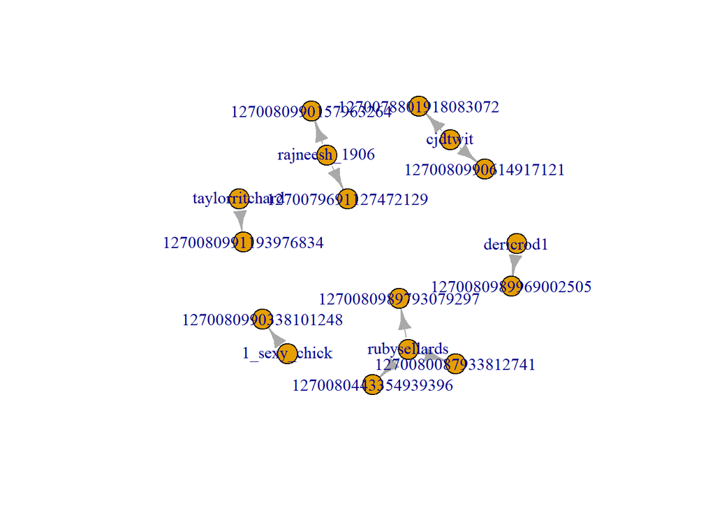

```r
dt_tweets[1:10, ] %>%
  gt_edges(screen_name, status_id) %>%
  gt_graph() %>%
  plot()
```

El grafico presentado no ofrece mayor información.

## Comparativo respecto a su rival de campania, el democrata, Joe Biden.

En este apartado repetire en mayor medida el codigo ya desarrollado con el fin de estabecer alguna suerte de comparativo entre candidatos, en tal sentido, analizar los sentimientos en terminos relativos y no absolutos en cada candidato.

```r
#jb_tweets <- search_tweets("JoeBiden", n = 18000, include_rts = FALSE)
```

```r
#save(jb_tweets, file = './dt_tweets_2020-06-08_JoeBiden.RData')
```

```r
load('./dt_tweets_2020-06-08_JoeBiden.RData')
```

```r
dim(jb_tweets)
```

```
## [1] 17995    90
```

Repetimos lo realizado para los twitts de trump.

```r
jb_txt <- jb_tweets$text
jb_txt <- gsub("(RT|via)((?:\\b\\W*@\\w+)+)", "", jb_txt)
jb_txt <-  gsub("\\bhttp[a-zA-Z0-9]*\\b", "", jb_txt)
jb_txt <- gsub("[[:punct:]]", "", jb_txt)
jb_txt <- gsub("amp ", "", jb_txt)
jb_txt <- gsub("[^a-zA-Z0-9 ]", "", jb_txt)
jb_txt <-  gsub("\\btco[a-zA-Z0-9]*\\b", "", jb_txt)
jb_txt <- jb_txt[!is.na(jb_txt)]
jb_txt <- iconv(jb_txt, 'UTF-8', 'ASCII')
jb_txt <- tolower(jb_txt)
jb_txt <- gsub("[ \t]{2,}", "", jb_txt)
jb_txt <- gsub("^\\s+|\\s+$", "", jb_txt)
head(jb_txt, 10)
```

```
##  [1] "mostlysanejane brycetache realdonaldtrump joebiden voting green its avote green its avote green"
##  [2] "speakerpelosi senschumer dnc cnn msnbc nbcnews abcpolitics cbsnews washingtonpost nytimes berniesanders joebiden amyklobuchar petebuttigieg ericswalwell ewarren mikebloomberg tomsteyer repadamschiff repjerrynadlershe speaks truth"
##  [3] "brycetache realdonaldtrump joebiden"
##  [4] "thepubliususa joebiden kamalaharris speakerpelosi we might just have a snowballs chance"
##  [5] "proviewsusa joebiden dnc i dont get it whats with the hammerhead sharks lol"
##  [6] "squillwhispers truthseeker126 realdonaldtrump how come i dont see any boats with joe biden flag on it joebiden"
##  [7] "danielthescot luckymor vinlandfr joebiden actually yes since its the contest between 2 persons plus what is shown about biden is just images with many possible explanations while trump went on record talking about abusing women and a long list of accusations and law suits"
##  [8] "usapatriot4maga ryree atlantapolice stopcrimeatl joebiden and i cant find that its a fact he refused blacks other than section8 and welfare"
##  [9] "usapatriot4maga ryree atlantapolice stopcrimeatl joebiden bottom line theyre all in it together red blue isnt has divided as they want us all to believe but we all are and i can only imagine how they are laughing about that"
## [10] "usapatriot4maga ryree atlantapolice stopcrimeatl joebiden we dont need to fact check that lol ive seen enough of those videos"
```

Vemos como ha quedado el Texto.

```r
# head(sapply(rc_tweets, function(x) x$getText()), 10)
head(jb_tweets$text, 10)
```

```
##  [1] "@mostlysanejane @brycetache @realDonaldTrump @JoeBiden Voting GREEN! 💚💚💚💚💚💚💚💚💚💚💚💚💚💚💚💚💚💚💚💚💚💚💚💚💚💚💚💚💚💚💚💚💚💚💚💚It’s a 🔒💚💚💚💚💚💚 Vote GREEN! 💚💚💚💚💚💚💚💚💚💚💚💚💚💚💚💚💚💚💚💚💚💚💚💚💚💚💚💚💚💚💚💚💚💚💚💚It’s a 🔒💚💚💚💚💚 Vote GREEN! 💚💚💚💚💚💚💚💚💚💚💚💚💚💚💚💚💚💚💚💚💚💚💚💚💚💚💚"
##  [2] "@SpeakerPelosi @SenSchumer @DNC @CNN @MSNBC @NBCNews @ABCPolitics @CBSNews @washingtonpost @nytimes @BernieSanders @JoeBiden @amyklobuchar @PeteButtigieg @ericswalwell @ewarren @MikeBloomberg @TomSteyer @RepAdamSchiff @RepJerryNadler\n\nShe speaks TRUTH https://t.co/IwskIyb6CR"
##  [3] "@brycetache @realDonaldTrump @JoeBiden 🖐"
##  [4] "@ThePubliusUSA @JoeBiden @KamalaHarris @SpeakerPelosi We might just have a snowball's chance."
##  [5] "@proviewsusa @JoeBiden @DNC I don't get it. What's with the hammerhead sharks? lol."
##  [6] "@Squill_whispers @Truthseeker126 @realDonaldTrump how come I dont see any boats with Joe Biden flag on it? 🧐😭😭😭😭😭😭😭\n#JoeBiden"
##  [7] "@daniel_the_scot @luckymor @VinlandFr @JoeBiden Actually yes, since it's the contest between 2 persons. Plus, what is shown about Biden is just images with many possible explanations while Trump went on record talking about abusing women. And a long list of accusations and law suits."
##  [8] "@USAPATRIOT4MAGA @ryree @Atlanta_Police @StopCrimeATL @JoeBiden And I can’t find that it’s a fact he refused “blacks” other than section8 and welfare."
##  [9] "@USAPATRIOT4MAGA @ryree @Atlanta_Police @StopCrimeATL @JoeBiden Bottom line. They’re all in it together. Red &amp; Blue isn’t has divided as they want us all to believe. But we all are and I can only imagine how they are laughing about that!"
## [10] "@USAPATRIOT4MAGA @ryree @Atlanta_Police @StopCrimeATL @JoeBiden We don’t need to fact check that lol... I’ve seen enough of those videos 🤮"
```

Finalmente Limpio.

```r
head(jb_txt, 10)
```

```
##  [1] "mostlysanejane brycetache realdonaldtrump joebiden voting green its avote green its avote green"
##  [2] "speakerpelosi senschumer dnc cnn msnbc nbcnews abcpolitics cbsnews washingtonpost nytimes berniesanders joebiden amyklobuchar petebuttigieg ericswalwell ewarren mikebloomberg tomsteyer repadamschiff repjerrynadlershe speaks truth"
##  [3] "brycetache realdonaldtrump joebiden"
##  [4] "thepubliususa joebiden kamalaharris speakerpelosi we might just have a snowballs chance"
##  [5] "proviewsusa joebiden dnc i dont get it whats with the hammerhead sharks lol"
##  [6] "squillwhispers truthseeker126 realdonaldtrump how come i dont see any boats with joe biden flag on it joebiden"
##  [7] "danielthescot luckymor vinlandfr joebiden actually yes since its the contest between 2 persons plus what is shown about biden is just images with many possible explanations while trump went on record talking about abusing women and a long list of accusations and law suits"
##  [8] "usapatriot4maga ryree atlantapolice stopcrimeatl joebiden and i cant find that its a fact he refused blacks other than section8 and welfare"
##  [9] "usapatriot4maga ryree atlantapolice stopcrimeatl joebiden bottom line theyre all in it together red blue isnt has divided as they want us all to believe but we all are and i can only imagine how they are laughing about that"
## [10] "usapatriot4maga ryree atlantapolice stopcrimeatl joebiden we dont need to fact check that lol ive seen enough of those videos"
```

### Clasificar emociones

Empezamos clasificando emociones con *classify_emotion* usando un algoritmo de Bayes

```r
jb_class_emo <- classify_emotion(jb_txt, algorithm="bayes", prior=1.0)
```

La función nos retorna 7 columnas: anger, disgust, fear, joy, sadness, surprise y best_fit para cada fila del documento

```r
head(jb_class_emo)
```

```
##      ANGER              DISGUST            FEAR
## [1,] "1.46871776464786" "3.09234031207392" "2.06783599555953"
## [2,] "1.46871776464786" "3.09234031207392" "2.06783599555953"
## [3,] "1.46871776464786" "3.09234031207392" "2.06783599555953"
## [4,] "1.46871776464786" "3.09234031207392" "2.06783599555953"
## [5,] "1.46871776464786" "3.09234031207392" "2.06783599555953"
## [6,] "1.46871776464786" "3.09234031207392" "2.06783599555953"
##      JOY                SADNESS            SURPRISE           BEST_FIT
## [1,] "1.02547755260094" "1.7277074477352"  "2.78695866252273" NA
## [2,] "1.02547755260094" "1.7277074477352"  "2.78695866252273" NA
## [3,] "1.02547755260094" "1.7277074477352"  "2.78695866252273" NA
## [4,] "1.02547755260094" "1.7277074477352"  "2.78695866252273" NA
## [5,] "1.02547755260094" "7.34083555412328" "7.34083555412327" "sadness"
## [6,] "1.02547755260094" "1.7277074477352"  "2.78695866252273" NA
```

Guardamos la que según el algoritmo encaja mejor (BEST_FIT).

```r
# Guardamos en el objeto emotion
emotionjb <- jb_class_emo[, 7]

# Y lo vemos en una tabla
table(emotionjb, useNA = 'ifany')
```

```
## emotionjb
##    anger  disgust     fear      joy  sadness surprise     <NA>
##      572      198      246     2910      890      245    12934
```

Para facilitar la clasificación, vamos a substituir los NAs por unknown

```r
emotionjb[is.na(emotionjb)] <- "unknown"
table(emotionjb, useNA = 'ifany')
```

```
## emotionjb
##    anger  disgust     fear      joy  sadness surprise  unknown
##      572      198      246     2910      890      245    12934
```

Presento la información en un grafico de barras.

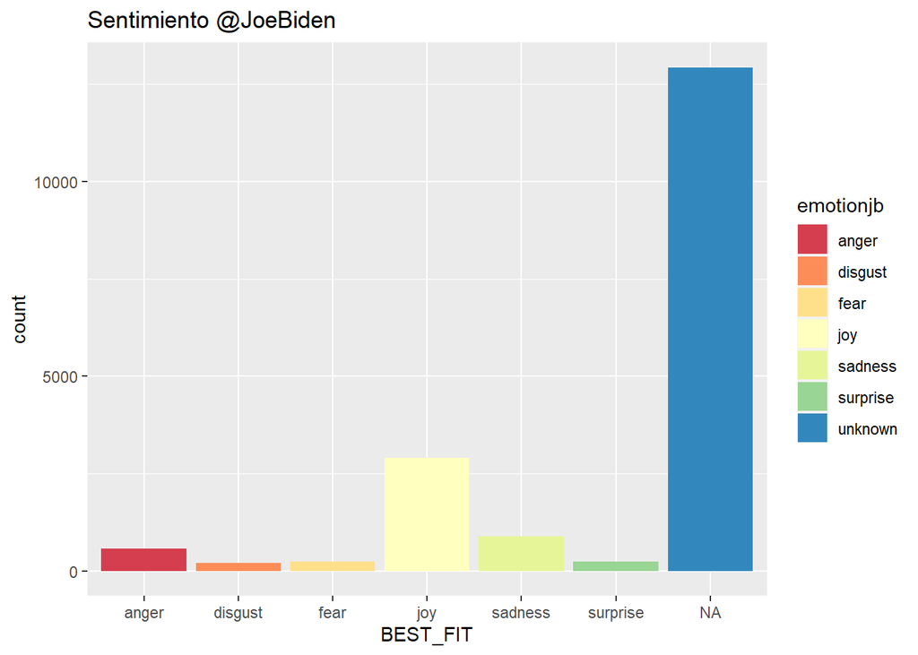

```r
jb <- ggplot(as.data.frame(jb_class_emo), aes(x = BEST_FIT)) +
 geom_bar() + labs(title = 'Sentimiento @JoeBiden') + geom_bar(aes(y=..count.., fill=emotionjb)) +
      scale_fill_brewer(palette="Spectral")
jb
```

Ahora obtenemos la polaridad. Clasificamos el texto en cuatro categorías:

- POS: Sentimiento positivo
- NEG: Sentimiento negativo
- POS/NEG: Indefinido
- BEST_FIT: La mas probable

```r
jb_class_pol <- classify_polarity(jb_txt, algorithm="bayes")
head(jb_class_pol, 3)
```

```
##      POS                NEG                 POS/NEG            BEST_FIT
## [1,] "1.03127774142571" "0.445453222112551" "2.31512017476245" "positive"
## [2,] "9.47547003995745" "0.445453222112551" "21.2715265477714" "positive"
## [3,] "1.03127774142571" "0.445453222112551" "2.31512017476245" "positive"
```

Como antes, creamos un objeto con el resultado, en este caso la polaridad

```r
polarityjb <- jb_class_pol[, 4]
head(polarityjb)
```

```
## [1] "positive" "positive" "positive" "positive" "negative" "positive"
```

En una tabla

```r
table(polarityjb, useNA = 'ifany')
```

```
## polarityjb
## negative  neutral positive
##     4656     2456    10883
```

Recopilamos la información en un dataframe

```r
sentiment_dataframejb <- data.frame(text     = jb_txt,
                                  emotion  = emotionjb,
                                  polarity = polarityjb, stringsAsFactors=FALSE)
head(sentiment_dataframejb)
```

```
##                                                                                                                                                                                                                                    text
## 1                                                                                                                                       mostlysanejane brycetache realdonaldtrump joebiden voting green its avote green its avote green
## 2 speakerpelosi senschumer dnc cnn msnbc nbcnews abcpolitics cbsnews washingtonpost nytimes berniesanders joebiden amyklobuchar petebuttigieg ericswalwell ewarren mikebloomberg tomsteyer repadamschiff repjerrynadlershe speaks truth
## 3                                                                                                                                                                                                   brycetache realdonaldtrump joebiden
## 4                                                                                                                                               thepubliususa joebiden kamalaharris speakerpelosi we might just have a snowballs chance
## 5                                                                                                                                                           proviewsusa joebiden dnc i dont get it whats with the hammerhead sharks lol
## 6                                                                                                                        squillwhispers truthseeker126 realdonaldtrump how come i dont see any boats with joe biden flag on it joebiden
##   emotion polarity
## 1 unknown positive
## 2 unknown positive
## 3 unknown positive
## 4 unknown positive
## 5 sadness negative
## 6 unknown positive
```

Lo reordenamos

```r
sentiment_dataframejb <- within(sentiment_dataframejb, emotionjb <- factor(emotionjb, levels=names(sort(table(emotionjb), decreasing=TRUE))))
head(sentiment_dataframejb)
```

```
##                                                                                                                                                                                                                                    text
## 1                                                                                                                                       mostlysanejane brycetache realdonaldtrump joebiden voting green its avote green its avote green
## 2 speakerpelosi senschumer dnc cnn msnbc nbcnews abcpolitics cbsnews washingtonpost nytimes berniesanders joebiden amyklobuchar petebuttigieg ericswalwell ewarren mikebloomberg tomsteyer repadamschiff repjerrynadlershe speaks truth
## 3                                                                                                                                                                                                   brycetache realdonaldtrump joebiden
## 4                                                                                                                                               thepubliususa joebiden kamalaharris speakerpelosi we might just have a snowballs chance
## 5                                                                                                                                                           proviewsusa joebiden dnc i dont get it whats with the hammerhead sharks lol
## 6                                                                                                                        squillwhispers truthseeker126 realdonaldtrump how come i dont see any boats with joe biden flag on it joebiden
##   emotion polarity emotionjb
## 1 unknown positive   unknown
## 2 unknown positive   unknown
## 3 unknown positive   unknown
## 4 unknown positive   unknown
## 5 sadness negative   sadness
## 6 unknown positive   unknown
```

### Gráficos

Número de Tweets clasificados por categorías

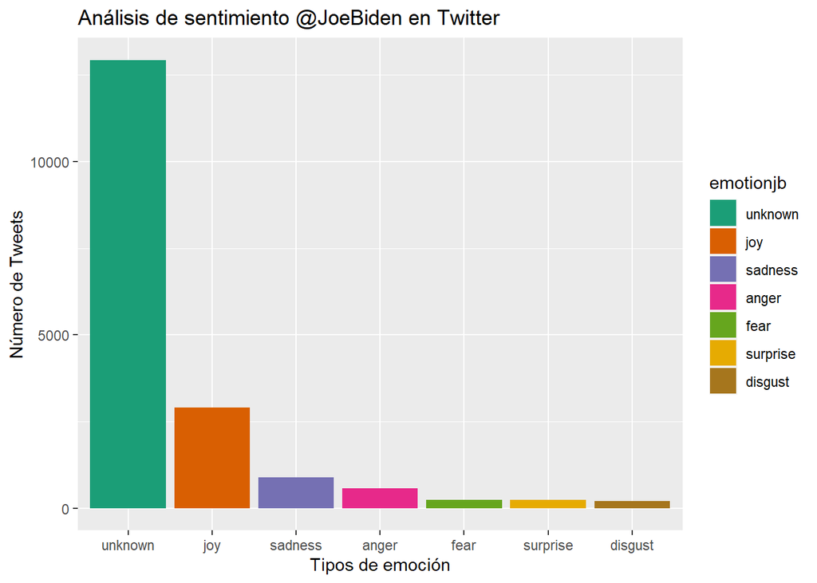

```r
ggplot(sentiment_dataframejb, aes(x = emotionjb)) + geom_bar(aes(y = ..count.., fill = emotionjb)) +
      scale_fill_brewer(palette = "Dark2") +
      ggtitle("Análisis de sentimiento @JoeBiden en Twitter") +
      theme(legend.position="right") + ylab("Número de Tweets") + xlab("Tipos de emoción")
```

Polaridad por tweets

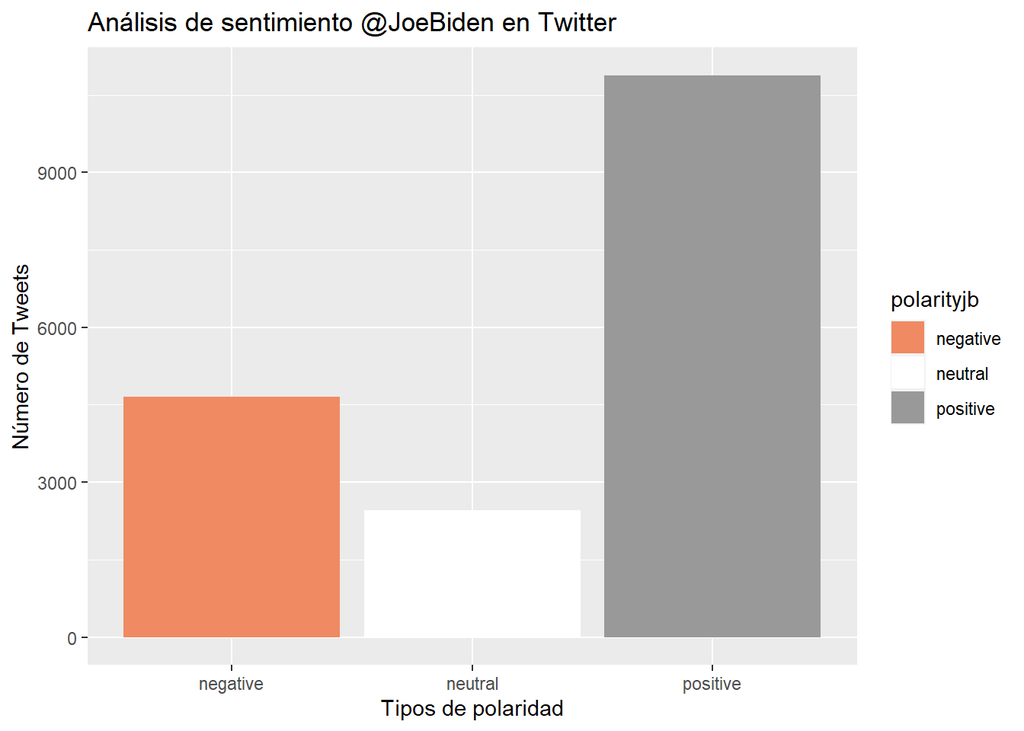

```r
ggplot(sentiment_dataframejb, aes(x = polarityjb)) +
      geom_bar(aes(y = ..count.., fill = polarityjb)) +
      scale_fill_brewer(palette = "RdGy") +
      ggtitle("Análisis de sentimiento @JoeBiden en Twitter") +
      theme(legend.position="right") + ylab("Número de Tweets") + xlab("Tipos de polaridad")
```

Separamos las palabras según las emociones

```r
jb_emos     <- levels(factor(sentiment_dataframejb$emotionjb))
n_jb_emos  <- length(jb_emos)
jb_emo_docs <- rep("", n_jb_emos)
for (i in 1:n_jb_emos)
{
      tmp <- jb_txt[emotionjb == jb_emos[i]]
      jb_emo_docs[i] <- paste(tmp, collapse=" ")
}
```

Lo vemos

```r
head(jb_emos)
```

```
## [1] "unknown"  "joy"      "sadness"  "anger"    "fear"     "surprise"
```

Creamos un corpus

```r
jb_corpus <- Corpus(VectorSource(jb_txt))
inspect(jb_corpus[1:10])
```

```
## <<SimpleCorpus>>
## Metadata:  corpus specific: 1, document level (indexed): 0
## Content:  documents: 10
##
##  [1] mostlysanejane brycetache realdonaldtrump joebiden voting green its avote green its avote green
##  [2] speakerpelosi senschumer dnc cnn msnbc nbcnews abcpolitics cbsnews washingtonpost nytimes berniesanders joebiden amyklobuchar petebuttigieg ericswalwell ewarren mikebloomberg tomsteyer repadamschiff repjerrynadlershe speaks truth
##  [3] brycetache realdonaldtrump joebiden
##  [4] thepubliususa joebiden kamalaharris speakerpelosi we might just have a snowballs chance
##  [5] proviewsusa joebiden dnc i dont get it whats with the hammerhead sharks lol
##  [6] squillwhispers truthseeker126 realdonaldtrump how come i dont see any boats with joe biden flag on it joebiden
##  [7] danielthescot luckymor vinlandfr joebiden actually yes since its the contest between 2 persons plus what is shown about biden is just images with many possible explanations while trump went on record talking about abusing women and a long list of accusations and law suits
##  [8] usapatriot4maga ryree atlantapolice stopcrimeatl joebiden and i cant find that its a fact he refused blacks other than section8 and welfare
##  [9] usapatriot4maga ryree atlantapolice stopcrimeatl joebiden bottom line theyre all in it together red blue isnt has divided as they want us all to believe but we all are and i can only imagine how they are laughing about that
## [10] usapatriot4maga ryree atlantapolice stopcrimeatl joebiden we dont need to fact check that lol ive seen enough of those videos
```

Lo podemos limpiar con *tm_map*

```r
# Pasamos a minúsculas
corpus_cleanjb <- tm_map(jb_corpus, tolower)
# Quitamos los números
corpus_cleanjb <- tm_map(corpus_cleanjb, removeNumbers)
# Quitamos puntauación
corpus_cleanjb <- tm_map(corpus_cleanjb, removePunctuation)
# Quitamos stopwords
corpus_cleanjb <- tm_map(corpus_cleanjb, removeWords, stopwords())
# Quitamos espacios en blanco
corpus_cleanjb <- tm_map(corpus_cleanjb, stripWhitespace)
```

Un tdm (Term Document Matrix)

```r
# jb_tdm           <- TermDocumentMatrix(jb_corpus, control = list(stopwords = TRUE))
# jb_tdm           <- as.matrix(jb_tdm)
```

Un dtm (Document-Term Matrix)

```r
jb_dtm <- DocumentTermMatrix(jb_corpus, control = list(minWordLength = 1,
                                                       stopwords = TRUE))
inspect(jb_dtm)
```

```
## <<DocumentTermMatrix (documents: 17995, terms: 29554)>>
## Non-/sparse entries: 223665/531600565
## Sparsity           : 100%
## Maximal term length: 228
## Weighting          : term frequency (tf)
## Sample             :
##        Terms
## Docs    biden brycetache joe joebiden like people ppact realdonaldtrump trump
##   12839     0          0   0        1    0      0     0               0     0
##   1610      0          0   0        1    0      0     0               1     0
##   1685      0          0   0        1    0      0     0               1     2
##   1732      0          0   0        1    0      2     0               1     0
##   1734      0          0   0        1    0      2     0               1     0
##   1749      0          0   0        1    0      1     0               1     0
##   1753      0          0   0        1    0      1     0               1     0
##   281       0          0   0        1    0      0     0               1     1
##   3147      0          0   0        1    0      0     0               1     0
##   775       1          0   0        1    0      0     0               1     0
##        Terms
## Docs    will
##   12839    0
##   1610     0
##   1685     0
##   1732     0
##   1734     0
##   1749     0
##   1753     0
##   281      0
##   3147     0
##   775      0
```

Hacemos el stem

```r
jb_corpus_stem <- tm_map(jb_corpus, stemDocument)
jb_corpus_stem <- tm_map(jb_corpus_stem, stemCompletion, dictionary = jb_corpus)
inspect(jb_corpus_stem[1:5])
```

```
## <<SimpleCorpus>>
## Metadata:  corpus specific: 1, document level (indexed): 0
## Content:  documents: 5
##
##                                                                                                                              mostlysanejan brycetach realdonaldtrump joebiden vote green it avot green it avot green
##
## speakerpelosi senschum dnc cnn msnbc nbcnew abcpolit cbsnew washingtonpost nytim berniesand joebiden amyklobuchar petebuttigieg ericswalwel ewarren mikebloomberg tomstey repadamschiff repjerrynadlersh speak truth
##
##                                                                                                                                                                                   brycetach realdonaldtrump joebiden
##
##                                                                                                                                  thepubliususa joebiden kamalaharri speakerpelosi we might just have a snowbal chanc
##
##                                                                                                                                            proviewsusa joebiden dnc i dont get it what with the hammerhead shark lol
##
```

Los términos frecuentes

```r
head(findFreqTerms(jb_dtm, lowfreq=10), 20)
```

```
##  [1] "brycetache"      "green"           "joebiden"        "realdonaldtrump"
##  [5] "voting"          "amyklobuchar"    "berniesanders"   "cbsnews"
##  [9] "cnn"             "dnc"             "ewarren"         "mikebloomberg"
## [13] "msnbc"           "nbcnews"         "nytimes"         "petebuttigieg"
## [17] "repadamschiff"   "senschumer"      "speakerpelosi"   "speaks"
```

Vamos a ver qué palabras están mas asociadas a la palabra “campaign” / Campania electoral

```r
findAssocs(jb_dtm, 'campaign', 0.10)
```

```
## $campaign
##             existing              tracked              finance
##                 0.23                 0.23                 0.18
##            donations            operative       ronaldjmoeller
##                 0.15                 0.15                 0.15
##             occasion               themes               fueled
##                 0.15                 0.15                 0.15
##            hisonline              jointly              tripled
##                 0.15                 0.15                 0.15
##                 dlcc   joebidendncwarroom statetcocwj9tsprajor
##                 0.15                 0.15                 0.15
##                stump               armors             everweak
##                 0.15                 0.15                 0.15
##            happywait          harambefren         nothingworst
##                 0.15                 0.15                 0.15
##    ukraineukrainians        yourhisherpos               donate
##                 0.15                 0.15                 0.14
##             instance             texasdan              donated
##                 0.13                 0.12                 0.11
##           winetast3r              shining             lighting
##                 0.11                 0.11                 0.11
##            melfaith1            patriotic              launder
##                 0.11                 0.11                 0.11
##              actblue          fundraising                  808
##                 0.10                 0.10                 0.10
##              request
##                 0.10
```

Tambien las mas relacionadas con floyd

```r
findAssocs(jb_dtm, 'floyd', 0.10)
```

```
## $floyd
##                 george              klobochar                truthif
##                   0.58                   0.24                   0.24
##                  1that          assassination               eclipsed
##                   0.24                   0.24                   0.24
##                  excon  joebidentcoflcvi4kwef                   mlks
##                   0.24                   0.24                   0.24
##               inequity potusdonttrustjoebiden            delincuente
##                   0.24                   0.24                   0.24
##         desestabilizar                  detrs         estadounidense
##                   0.24                   0.24                   0.24
##               intentar                pilares              protestas
##                   0.24                   0.24                   0.24
##               repblica             sirvindose                socavar
##                   0.24                   0.24                   0.24
##              violentas             ofbenghazi               mistaken
##                   0.24                   0.24                   0.24
##                covidat                 gropey                 marked
##                   0.24                   0.24                   0.24
##               elephant                things1                  trunk
##                   0.24                   0.24                   0.24
##               digitsif              extending                 fallen
##                   0.24                   0.24                   0.19
##                   reed         demonstrations                partido
##                   0.18                   0.17                   0.17
##             exaggerate                pattern                   icon
##                   0.17                   0.17                   0.17
##                soldier               demcrata             democracia
##                   0.17                   0.17                   0.17
##                 equate                   howd               promoted
##                   0.17                   0.17                   0.14
##              scamdemic                  negro             americajoe
##                   0.14                   0.14                   0.14
##                 desean                 killed                  gates
##                   0.14                   0.12                   0.12
##             refreshing             astonished                chicago
##                   0.12                   0.12                   0.12
##               morbidly               gobierno               dangling
##                   0.12                   0.12                   0.12
##                    est               drewdmat                  kneel
##                   0.11                   0.10                   0.10
##                    808               presence                comfort
##                   0.10                   0.10                   0.10
##             importance               soldiers           mjax28nelson
##                   0.10                   0.10                   0.10
```

### Nube de palabras

Tras varios intentos con el minimo de frecuencia, para obtener una mejor nube subi la frecuencia minima.

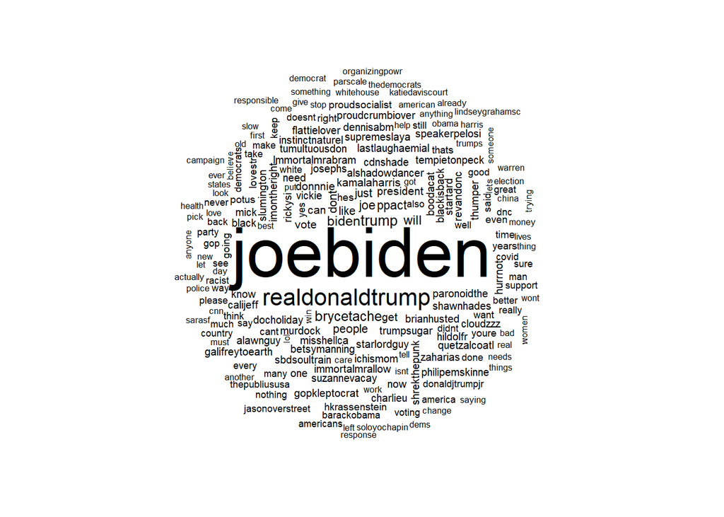

```r
wordcloud(corpus_cleanjb, min.freq = 150, random.order = FALSE)
```

### Seguidos

```r
jb_fds <- get_friends("JoeBiden")
jb_fds
```

```
## # A tibble: 26 x 2
##    user     user_id
##    <chr>    <chr>
##  1 JoeBiden 1141928541656952832
##  2 JoeBiden 1141929375639777280
##  3 JoeBiden 1141929016443777024
##  4 JoeBiden 1141928177046106114
##  5 JoeBiden 1129095209772552192
##  6 JoeBiden 609476852
##  7 JoeBiden 14230524
##  8 JoeBiden 2840712124
##  9 JoeBiden 821784477076750338
## 10 JoeBiden 869995492687716354
## # ... with 16 more rows
```

```r
jb_fds_data <- lookup_users(jb_fds$user_id)
jb_fds_data
```

```
## # A tibble: 26 x 90
##    user_id status_id created_at          screen_name text  source
##    <chr>   <chr>     <dttm>              <chr>       <chr> <chr>
##  1 114192~ 12317779~ 2020-02-24 03:08:36 JoeForNV    "Lov~ Twitt~
##  2 114192~ 12370354~ 2020-03-09 15:20:13 JoeForSC    "Oka~ Twitt~
##  3 114192~ 12721781~ 2020-06-14 14:44:43 JoeForNH    "Tom~ Twitt~
##  4 114192~ 12276704~ 2020-02-12 19:07:06 JoeForIA    "Tea~ Twitt~
##  5 112909~ 12733554~ 2020-06-17 20:43:00 TeamJoe     "Fro~ Tweet~
##  6 609476~ 12571058~ 2020-05-04 00:32:52 De11eDonne  "#Be~ Tweet~
##  7 142305~ 12729726~ 2020-06-16 19:21:45 ladygaga    "Sho~ Twitt~
##  8 284071~ 12733744~ 2020-06-17 21:58:20 ItsOnUs     "A s~ Twitt~
##  9 821784~ 12733608~ 2020-06-17 21:04:14 DrBiden     "Ema~ Twitt~
## 10 869995~ 12725987~ 2020-06-15 18:36:00 UDBidenInst "Lov~ Twitt~
## # ... with 16 more rows, and 84 more variables: display_text_width <int>,
## #   reply_to_status_id <chr>, reply_to_user_id <chr>,
## #   reply_to_screen_name <chr>, is_quote <lgl>, is_retweet <lgl>,
## #   favorite_count <int>, retweet_count <int>, quote_count <int>,
## #   reply_count <int>, hashtags <list>, symbols <list>, urls_url <list>,
## #   urls_t.co <list>, urls_expanded_url <list>, media_url <list>,
## #   media_t.co <list>, media_expanded_url <list>, media_type <list>,
## #   ext_media_url <list>, ext_media_t.co <list>, ext_media_expanded_url <list>,
## #   ext_media_type <chr>, mentions_user_id <list>, mentions_screen_name <list>,
## #   lang <chr>, quoted_status_id <chr>, quoted_text <chr>,
## #   quoted_created_at <dttm>, quoted_source <chr>, quoted_favorite_count <int>,
## #   quoted_retweet_count <int>, quoted_user_id <chr>, quoted_screen_name <chr>,
## #   quoted_name <chr>, quoted_followers_count <int>,
## #   quoted_friends_count <int>, quoted_statuses_count <int>,
## #   quoted_location <chr>, quoted_description <chr>, quoted_verified <lgl>,
## #   retweet_status_id <chr>, retweet_text <chr>, retweet_created_at <dttm>,
## #   retweet_source <chr>, retweet_favorite_count <int>,
## #   retweet_retweet_count <int>, retweet_user_id <chr>,
## #   retweet_screen_name <chr>, retweet_name <chr>,
## #   retweet_followers_count <int>, retweet_friends_count <int>,
## #   retweet_statuses_count <int>, retweet_location <chr>,
## #   retweet_description <chr>, retweet_verified <lgl>, place_url <chr>,
## #   place_name <chr>, place_full_name <chr>, place_type <chr>, country <chr>,
## #   country_code <chr>, geo_coords <list>, coords_coords <list>,
## #   bbox_coords <list>, status_url <chr>, name <chr>, location <chr>,
## #   description <chr>, url <chr>, protected <lgl>, followers_count <int>,
## #   friends_count <int>, listed_count <int>, statuses_count <int>,
## #   favourites_count <int>, account_created_at <dttm>, verified <lgl>,
## #   profile_url <chr>, profile_expanded_url <chr>, account_lang <lgl>,
## #   profile_banner_url <chr>, profile_background_url <chr>,
## #   profile_image_url <chr>
```

```r
jb_screen_name <- jb_fds_data[,4]
jb_screen_name
```

```
## # A tibble: 26 x 1
##    screen_name
##    <chr>
##  1 JoeForNV
##  2 JoeForSC
##  3 JoeForNH
##  4 JoeForIA
##  5 TeamJoe
##  6 De11eDonne
##  7 ladygaga
##  8 ItsOnUs
##  9 DrBiden
## 10 UDBidenInst
## # ... with 16 more rows
```

Tomo nota si Joe Biden sigue en la red social a su rival de campania.

```r
is.data.frame(jb_screen_name)
```

```
## [1] TRUE
```

```r
which(jb_screen_name$screen_name == "realDonaldTrump")
```

```
## integer(0)
```

Efectivamente no lo sigue, de lo contrario deberia de figurar el numero.

## Ver los tweets en gráfico

Instalamos la librería

```r
#install.packages("graphTweets") # CRAN release v0.4
#devtools::install_github("JohnCoene/graphTweets")
```

Vemos el gráfico

Uno pequeño ya que, tal como fue visto en clase, si es grande el grafico pierde sentido ya que no se logra divisar ninguna interaccion.

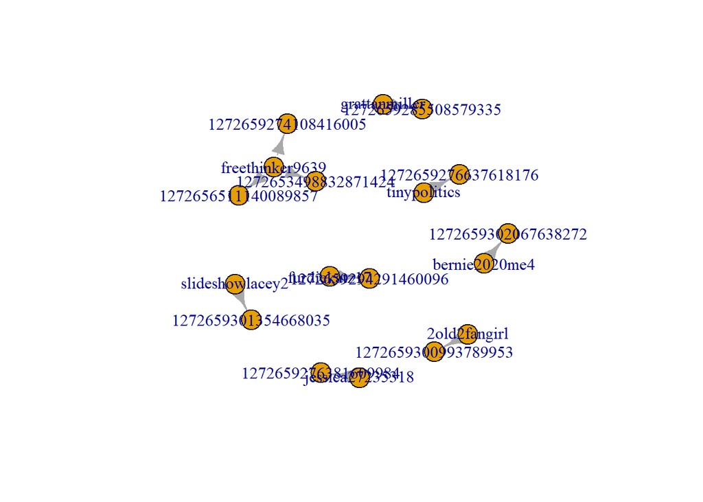

```r
jb_tweets[1:10, ] %>%
  gt_edges(screen_name, status_id) %>%
  gt_graph() %>%
  plot()
```

El grafico no ofrece mayor Información.

## Comparativo respecto a su rival de campania, el democrata, Joe Biden.

En este apartado repetire en mayor medida el codigo ya desarrollado con el fin de estabecer alguna suerte de comparativo entre candidatos, en tal sentido, analizar los sentimientos en terminos relativos y no absolutos en cada candidato.

```r
#jb_tweets <- search_tweets("JoeBiden", n = 18000, include_rts = FALSE)
```

```r
#save(jb_tweets, file = './dt_tweets_2020-06-08_JoeBiden.RData')
```

```r
load('./dt_tweets_2020-06-08_JoeBiden.RData')
```

```r
dim(jb_tweets)
```

```
## [1] 17995    90
```

Repetimos lo realizado para los twitts de trump.

```r
jb_txt <- jb_tweets$text
jb_txt <- gsub("(RT|via)((?:\\b\\W*@\\w+)+)", "", jb_txt)
jb_txt <-  gsub("\\bhttp[a-zA-Z0-9]*\\b", "", jb_txt)
jb_txt <- gsub("[[:punct:]]", "", jb_txt)
jb_txt <- gsub("amp ", "", jb_txt)
jb_txt <- gsub("[^a-zA-Z0-9 ]", "", jb_txt)
jb_txt <-  gsub("\\btco[a-zA-Z0-9]*\\b", "", jb_txt)
jb_txt <- jb_txt[!is.na(jb_txt)]
jb_txt <- iconv(jb_txt, 'UTF-8', 'ASCII')
jb_txt <- tolower(jb_txt)
jb_txt <- gsub("[ \t]{2,}", "", jb_txt)
jb_txt <- gsub("^\\s+|\\s+$", "", jb_txt)
head(jb_txt, 10)
```

```
##  [1] "mostlysanejane brycetache realdonaldtrump joebiden voting green its avote green its avote green"
##  [2] "speakerpelosi senschumer dnc cnn msnbc nbcnews abcpolitics cbsnews washingtonpost nytimes berniesanders joebiden amyklobuchar petebuttigieg ericswalwell ewarren mikebloomberg tomsteyer repadamschiff repjerrynadlershe speaks truth"
##  [3] "brycetache realdonaldtrump joebiden"
##  [4] "thepubliususa joebiden kamalaharris speakerpelosi we might just have a snowballs chance"
##  [5] "proviewsusa joebiden dnc i dont get it whats with the hammerhead sharks lol"
##  [6] "squillwhispers truthseeker126 realdonaldtrump how come i dont see any boats with joe biden flag on it joebiden"
##  [7] "danielthescot luckymor vinlandfr joebiden actually yes since its the contest between 2 persons plus what is shown about biden is just images with many possible explanations while trump went on record talking about abusing women and a long list of accusations and law suits"
##  [8] "usapatriot4maga ryree atlantapolice stopcrimeatl joebiden and i cant find that its a fact he refused blacks other than section8 and welfare"
##  [9] "usapatriot4maga ryree atlantapolice stopcrimeatl joebiden bottom line theyre all in it together red blue isnt has divided as they want us all to believe but we all are and i can only imagine how they are laughing about that"
## [10] "usapatriot4maga ryree atlantapolice stopcrimeatl joebiden we dont need to fact check that lol ive seen enough of those videos"
```

Vemos como ha quedado el Texto.

```r
# head(sapply(rc_tweets, function(x) x$getText()), 10)
head(jb_tweets$text, 10)
```

```
##  [1] "@mostlysanejane @brycetache @realDonaldTrump @JoeBiden Voting GREEN! 💚💚💚💚💚💚💚💚💚💚💚💚💚💚💚💚💚💚💚💚💚💚💚💚💚💚💚💚💚💚💚💚💚💚💚💚It’s a 🔒💚💚💚💚💚💚 Vote GREEN! 💚💚💚💚💚💚💚💚💚💚💚💚💚💚💚💚💚💚💚💚💚💚💚💚💚💚💚💚💚💚💚💚💚💚💚💚It’s a 🔒💚💚💚💚💚 Vote GREEN! 💚💚💚💚💚💚💚💚💚💚💚💚💚💚💚💚💚💚💚💚💚💚💚💚💚💚💚"
##  [2] "@SpeakerPelosi @SenSchumer @DNC @CNN @MSNBC @NBCNews @ABCPolitics @CBSNews @washingtonpost @nytimes @BernieSanders @JoeBiden @amyklobuchar @PeteButtigieg @ericswalwell @ewarren @MikeBloomberg @TomSteyer @RepAdamSchiff @RepJerryNadler\n\nShe speaks TRUTH https://t.co/IwskIyb6CR"
##  [3] "@brycetache @realDonaldTrump @JoeBiden 🖐"
##  [4] "@ThePubliusUSA @JoeBiden @KamalaHarris @SpeakerPelosi We might just have a snowball's chance."
##  [5] "@proviewsusa @JoeBiden @DNC I don't get it. What's with the hammerhead sharks? lol."
##  [6] "@Squill_whispers @Truthseeker126 @realDonaldTrump how come I dont see any boats with Joe Biden flag on it? 🧐😭😭😭😭😭😭😭\n#JoeBiden"
##  [7] "@daniel_the_scot @luckymor @VinlandFr @JoeBiden Actually yes, since it's the contest between 2 persons. Plus, what is shown about Biden is just images with many possible explanations while Trump went on record talking about abusing women. And a long list of accusations and law suits."
##  [8] "@USAPATRIOT4MAGA @ryree @Atlanta_Police @StopCrimeATL @JoeBiden And I can’t find that it’s a fact he refused “blacks” other than section8 and welfare."
##  [9] "@USAPATRIOT4MAGA @ryree @Atlanta_Police @StopCrimeATL @JoeBiden Bottom line. They’re all in it together. Red &amp; Blue isn’t has divided as they want us all to believe. But we all are and I can only imagine how they are laughing about that!"
## [10] "@USAPATRIOT4MAGA @ryree @Atlanta_Police @StopCrimeATL @JoeBiden We don’t need to fact check that lol... I’ve seen enough of those videos 🤮"
```

Finalmente Limpio.

```r
head(jb_txt, 10)
```

```
##  [1] "mostlysanejane brycetache realdonaldtrump joebiden voting green its avote green its avote green"
##  [2] "speakerpelosi senschumer dnc cnn msnbc nbcnews abcpolitics cbsnews washingtonpost nytimes berniesanders joebiden amyklobuchar petebuttigieg ericswalwell ewarren mikebloomberg tomsteyer repadamschiff repjerrynadlershe speaks truth"
##  [3] "brycetache realdonaldtrump joebiden"
##  [4] "thepubliususa joebiden kamalaharris speakerpelosi we might just have a snowballs chance"
##  [5] "proviewsusa joebiden dnc i dont get it whats with the hammerhead sharks lol"
##  [6] "squillwhispers truthseeker126 realdonaldtrump how come i dont see any boats with joe biden flag on it joebiden"
##  [7] "danielthescot luckymor vinlandfr joebiden actually yes since its the contest between 2 persons plus what is shown about biden is just images with many possible explanations while trump went on record talking about abusing women and a long list of accusations and law suits"
##  [8] "usapatriot4maga ryree atlantapolice stopcrimeatl joebiden and i cant find that its a fact he refused blacks other than section8 and welfare"
##  [9] "usapatriot4maga ryree atlantapolice stopcrimeatl joebiden bottom line theyre all in it together red blue isnt has divided as they want us all to believe but we all are and i can only imagine how they are laughing about that"
## [10] "usapatriot4maga ryree atlantapolice stopcrimeatl joebiden we dont need to fact check that lol ive seen enough of those videos"
```

### Clasificar emociones

Empezamos clasificando emociones con *classify_emotion* usando un algoritmo de Bayes

```r
jb_class_emo <- classify_emotion(jb_txt, algorithm="bayes", prior=1.0)
```

La función nos retorna 7 columnas: anger, disgust, fear, joy, sadness, surprise y best_fit para cada fila del documento

```r
head(jb_class_emo)
```

```
##      ANGER              DISGUST            FEAR
## [1,] "1.46871776464786" "3.09234031207392" "2.06783599555953"
## [2,] "1.46871776464786" "3.09234031207392" "2.06783599555953"
## [3,] "1.46871776464786" "3.09234031207392" "2.06783599555953"
## [4,] "1.46871776464786" "3.09234031207392" "2.06783599555953"
## [5,] "1.46871776464786" "3.09234031207392" "2.06783599555953"
## [6,] "1.46871776464786" "3.09234031207392" "2.06783599555953"
##      JOY                SADNESS            SURPRISE           BEST_FIT
## [1,] "1.02547755260094" "1.7277074477352"  "2.78695866252273" NA
## [2,] "1.02547755260094" "1.7277074477352"  "2.78695866252273" NA
## [3,] "1.02547755260094" "1.7277074477352"  "2.78695866252273" NA
## [4,] "1.02547755260094" "1.7277074477352"  "2.78695866252273" NA
## [5,] "1.02547755260094" "7.34083555412328" "7.34083555412327" "sadness"
## [6,] "1.02547755260094" "1.7277074477352"  "2.78695866252273" NA
```

Guardamos la que según el algoritmo encaja mejor (BEST_FIT).

```r
# Guardamos en el objeto emotion
emotionjb <- jb_class_emo[, 7]

# Y lo vemos en una tabla
table(emotionjb, useNA = 'ifany')
```

```
## emotionjb
##    anger  disgust     fear      joy  sadness surprise     <NA>
##      572      198      246     2910      890      245    12934
```

Para facilitar la clasificación, vamos a substituir los NAs por unknown

```r
emotionjb[is.na(emotionjb)] <- "unknown"
table(emotionjb, useNA = 'ifany')
```

```
## emotionjb
##    anger  disgust     fear      joy  sadness surprise  unknown
##      572      198      246     2910      890      245    12934
```

Presento la información en un grafico de barras.

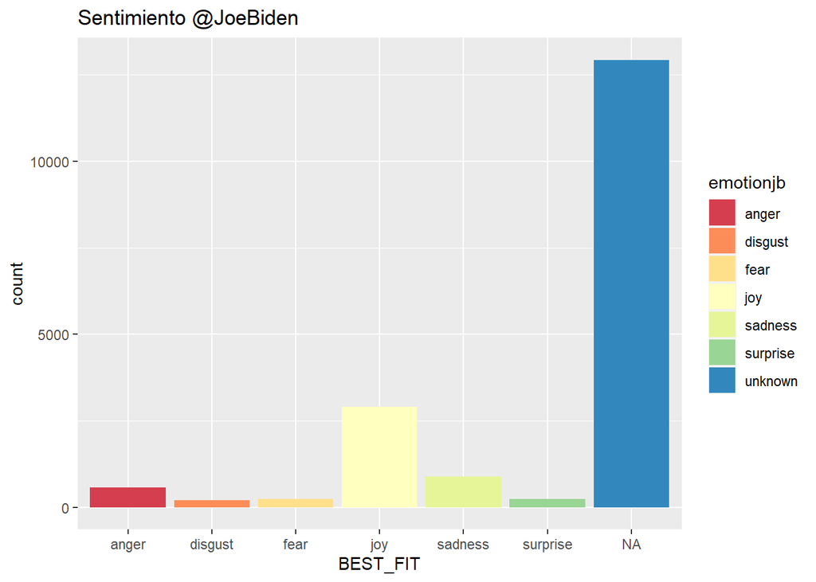

```r
jb <- ggplot(as.data.frame(jb_class_emo), aes(x = BEST_FIT)) +
 geom_bar() + labs(title = 'Sentimiento @JoeBiden') + geom_bar(aes(y=..count.., fill=emotionjb)) +
      scale_fill_brewer(palette="Spectral")
jb
```

Ahora obtenemos la polaridad. Clasificamos el texto en cuatro categorías:

- POS: Sentimiento positivo
- NEG: Sentimiento negativo
- POS/NEG: Indefinido
- BEST_FIT: La mas probable

```r
jb_class_pol <- classify_polarity(jb_txt, algorithm="bayes")
head(jb_class_pol, 3)
```

```
##      POS                NEG                 POS/NEG            BEST_FIT
## [1,] "1.03127774142571" "0.445453222112551" "2.31512017476245" "positive"
## [2,] "9.47547003995745" "0.445453222112551" "21.2715265477714" "positive"
## [3,] "1.03127774142571" "0.445453222112551" "2.31512017476245" "positive"
```

Como antes, creamos un objeto con el resultado, en este caso la polaridad

```r
polarityjb <- jb_class_pol[, 4]
head(polarityjb)
```

```
## [1] "positive" "positive" "positive" "positive" "negative" "positive"
```

En una tabla

```r
table(polarityjb, useNA = 'ifany')
```

```
## polarityjb
## negative  neutral positive
##     4656     2456    10883
```

Recopilamos la información en un dataframe

```r
sentiment_dataframejb <- data.frame(text     = jb_txt,
                                  emotion  = emotionjb,
                                  polarity = polarityjb, stringsAsFactors=FALSE)
head(sentiment_dataframejb)
```

```
##                                                                                                                                                                                                                                    text
## 1                                                                                                                                       mostlysanejane brycetache realdonaldtrump joebiden voting green its avote green its avote green
## 2 speakerpelosi senschumer dnc cnn msnbc nbcnews abcpolitics cbsnews washingtonpost nytimes berniesanders joebiden amyklobuchar petebuttigieg ericswalwell ewarren mikebloomberg tomsteyer repadamschiff repjerrynadlershe speaks truth
## 3                                                                                                                                                                                                   brycetache realdonaldtrump joebiden
## 4                                                                                                                                               thepubliususa joebiden kamalaharris speakerpelosi we might just have a snowballs chance
## 5                                                                                                                                                           proviewsusa joebiden dnc i dont get it whats with the hammerhead sharks lol
## 6                                                                                                                        squillwhispers truthseeker126 realdonaldtrump how come i dont see any boats with joe biden flag on it joebiden
##   emotion polarity
## 1 unknown positive
## 2 unknown positive
## 3 unknown positive
## 4 unknown positive
## 5 sadness negative
## 6 unknown positive
```

Lo reordenamos

```r
sentiment_dataframejb <- within(sentiment_dataframejb, emotionjb <- factor(emotionjb, levels=names(sort(table(emotionjb), decreasing=TRUE))))
head(sentiment_dataframejb)
```

```
##                                                                                                                                                                                                                                    text
## 1                                                                                                                                       mostlysanejane brycetache realdonaldtrump joebiden voting green its avote green its avote green
## 2 speakerpelosi senschumer dnc cnn msnbc nbcnews abcpolitics cbsnews washingtonpost nytimes berniesanders joebiden amyklobuchar petebuttigieg ericswalwell ewarren mikebloomberg tomsteyer repadamschiff repjerrynadlershe speaks truth
## 3                                                                                                                                                                                                   brycetache realdonaldtrump joebiden
## 4                                                                                                                                               thepubliususa joebiden kamalaharris speakerpelosi we might just have a snowballs chance
## 5                                                                                                                                                           proviewsusa joebiden dnc i dont get it whats with the hammerhead sharks lol
## 6                                                                                                                        squillwhispers truthseeker126 realdonaldtrump how come i dont see any boats with joe biden flag on it joebiden
##   emotion polarity emotionjb
## 1 unknown positive   unknown
## 2 unknown positive   unknown
## 3 unknown positive   unknown
## 4 unknown positive   unknown
## 5 sadness negative   sadness
## 6 unknown positive   unknown
```

### Gráficos

Número de Tweets clasificados por categorías

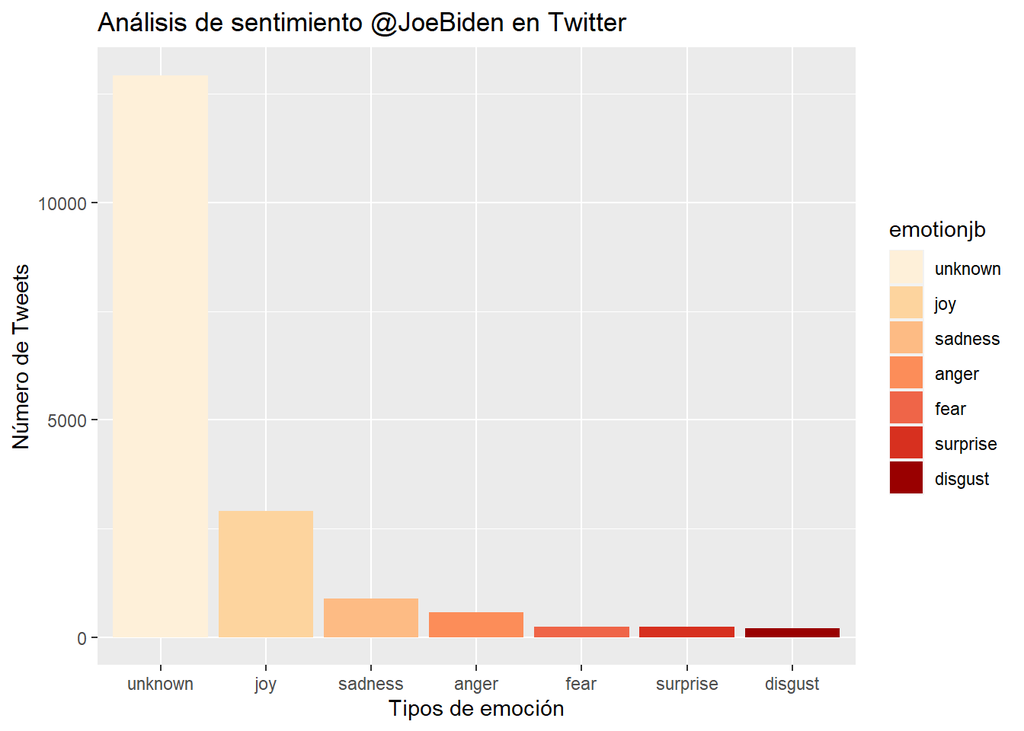

```r
ggplot(sentiment_dataframejb, aes(x = emotionjb)) + geom_bar(aes(y = ..count.., fill = emotionjb)) +
      scale_fill_brewer(palette = "OrRd") +
      ggtitle("Análisis de sentimiento @JoeBiden en Twitter") +
      theme(legend.position="right") + ylab("Número de Tweets") + xlab("Tipos de emoción")
```

Polaridad por tweets

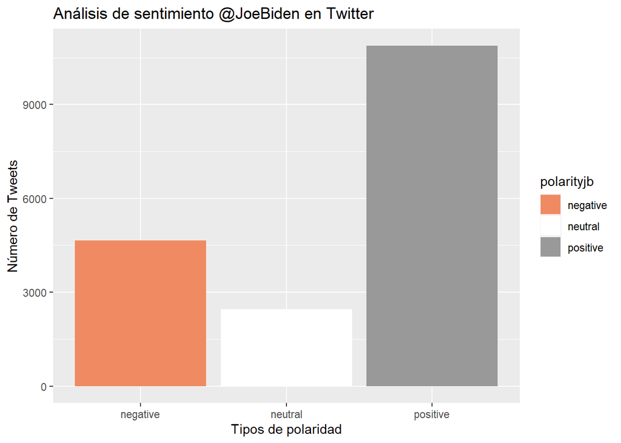

```r
ggplot(sentiment_dataframejb, aes(x = polarityjb)) +
      geom_bar(aes(y = ..count.., fill = polarityjb)) +
      scale_fill_brewer(palette = "RdGy") +
      ggtitle("Análisis de sentimiento @JoeBiden en Twitter") +
      theme(legend.position="right") + ylab("Número de Tweets") + xlab("Tipos de polaridad")
```

Separamos las palabras según las emociones

```r
jb_emos     <- levels(factor(sentiment_dataframejb$emotionjb))
n_jb_emos  <- length(jb_emos)
jb_emo_docs <- rep("", n_jb_emos)
for (i in 1:n_jb_emos)
{
      tmp <- jb_txt[emotionjb == jb_emos[i]]
      jb_emo_docs[i] <- paste(tmp, collapse=" ")
}
```

Lo vemos

```r
head(jb_emos)
```

```
## [1] "unknown"  "joy"      "sadness"  "anger"    "fear"     "surprise"
```

Creamos un corpus

```r
jb_corpus <- Corpus(VectorSource(jb_txt))
inspect(jb_corpus[1:10])
```

```
## <<SimpleCorpus>>
## Metadata:  corpus specific: 1, document level (indexed): 0
## Content:  documents: 10
##
##  [1] mostlysanejane brycetache realdonaldtrump joebiden voting green its avote green its avote green
##  [2] speakerpelosi senschumer dnc cnn msnbc nbcnews abcpolitics cbsnews washingtonpost nytimes berniesanders joebiden amyklobuchar petebuttigieg ericswalwell ewarren mikebloomberg tomsteyer repadamschiff repjerrynadlershe speaks truth
##  [3] brycetache realdonaldtrump joebiden
##  [4] thepubliususa joebiden kamalaharris speakerpelosi we might just have a snowballs chance
##  [5] proviewsusa joebiden dnc i dont get it whats with the hammerhead sharks lol
##  [6] squillwhispers truthseeker126 realdonaldtrump how come i dont see any boats with joe biden flag on it joebiden
##  [7] danielthescot luckymor vinlandfr joebiden actually yes since its the contest between 2 persons plus what is shown about biden is just images with many possible explanations while trump went on record talking about abusing women and a long list of accusations and law suits
##  [8] usapatriot4maga ryree atlantapolice stopcrimeatl joebiden and i cant find that its a fact he refused blacks other than section8 and welfare
##  [9] usapatriot4maga ryree atlantapolice stopcrimeatl joebiden bottom line theyre all in it together red blue isnt has divided as they want us all to believe but we all are and i can only imagine how they are laughing about that
## [10] usapatriot4maga ryree atlantapolice stopcrimeatl joebiden we dont need to fact check that lol ive seen enough of those videos
```

Lo podemos limpiar con *tm_map*

```r
# Pasamos a minúsculas
corpus_cleanjb <- tm_map(jb_corpus, tolower)
# Quitamos los números
corpus_cleanjb <- tm_map(corpus_cleanjb, removeNumbers)
# Quitamos puntauación
corpus_cleanjb <- tm_map(corpus_cleanjb, removePunctuation)
# Quitamos stopwords
corpus_cleanjb <- tm_map(corpus_cleanjb, removeWords, stopwords())
# Quitamos espacios en blanco
corpus_cleanjb <- tm_map(corpus_cleanjb, stripWhitespace)
```

Un tdm (Term Document Matrix)

```r
# jb_tdm           <- TermDocumentMatrix(jb_corpus, control = list(stopwords = TRUE))
# jb_tdm           <- as.matrix(jb_tdm)
```

Un dtm (Document-Term Matrix)

```r
jb_dtm <- DocumentTermMatrix(jb_corpus, control = list(minWordLength = 1,
                                                       stopwords = TRUE))
inspect(jb_dtm)
```

```
## <<DocumentTermMatrix (documents: 17995, terms: 29554)>>
## Non-/sparse entries: 223665/531600565
## Sparsity           : 100%
## Maximal term length: 228
## Weighting          : term frequency (tf)
## Sample             :
##        Terms
## Docs    biden brycetache joe joebiden like people ppact realdonaldtrump trump
##   12839     0          0   0        1    0      0     0               0     0
##   1610      0          0   0        1    0      0     0               1     0
##   1685      0          0   0        1    0      0     0               1     2
##   1732      0          0   0        1    0      2     0               1     0
##   1734      0          0   0        1    0      2     0               1     0
##   1749      0          0   0        1    0      1     0               1     0
##   1753      0          0   0        1    0      1     0               1     0
##   281       0          0   0        1    0      0     0               1     1
##   3147      0          0   0        1    0      0     0               1     0
##   775       1          0   0        1    0      0     0               1     0
##        Terms
## Docs    will
##   12839    0
##   1610     0
##   1685     0
##   1732     0
##   1734     0
##   1749     0
##   1753     0
##   281      0
##   3147     0
##   775      0
```

Hacemos el stem

```r
jb_corpus_stem <- tm_map(jb_corpus, stemDocument)
jb_corpus_stem <- tm_map(jb_corpus_stem, stemCompletion, dictionary = jb_corpus)
inspect(jb_corpus_stem[1:5])
```

```
## <<SimpleCorpus>>
## Metadata:  corpus specific: 1, document level (indexed): 0
## Content:  documents: 5
##
##                                                                                                                              mostlysanejan brycetach realdonaldtrump joebiden vote green it avot green it avot green
##
## speakerpelosi senschum dnc cnn msnbc nbcnew abcpolit cbsnew washingtonpost nytim berniesand joebiden amyklobuchar petebuttigieg ericswalwel ewarren mikebloomberg tomstey repadamschiff repjerrynadlersh speak truth
##
##                                                                                                                                                                                   brycetach realdonaldtrump joebiden
##
##                                                                                                                                  thepubliususa joebiden kamalaharri speakerpelosi we might just have a snowbal chanc
##
##                                                                                                                                            proviewsusa joebiden dnc i dont get it what with the hammerhead shark lol
##
```

Los términos frecuentes

```r
head(findFreqTerms(jb_dtm, lowfreq=10), 20)
```

```
##  [1] "brycetache"      "green"           "joebiden"        "realdonaldtrump"
##  [5] "voting"          "amyklobuchar"    "berniesanders"   "cbsnews"
##  [9] "cnn"             "dnc"             "ewarren"         "mikebloomberg"
## [13] "msnbc"           "nbcnews"         "nytimes"         "petebuttigieg"
## [17] "repadamschiff"   "senschumer"      "speakerpelosi"   "speaks"
```

Vamos a ver qué palabras están mas asociadas a la palabra “campaign” / Campania electoral

```r
findAssocs(jb_dtm, 'campaign', 0.10)
```

```
## $campaign
##             existing              tracked              finance
##                 0.23                 0.23                 0.18
##            donations            operative       ronaldjmoeller
##                 0.15                 0.15                 0.15
##             occasion               themes               fueled
##                 0.15                 0.15                 0.15
##            hisonline              jointly              tripled
##                 0.15                 0.15                 0.15
##                 dlcc   joebidendncwarroom statetcocwj9tsprajor
##                 0.15                 0.15                 0.15
##                stump               armors             everweak
##                 0.15                 0.15                 0.15
##            happywait          harambefren         nothingworst
##                 0.15                 0.15                 0.15
##    ukraineukrainians        yourhisherpos               donate
##                 0.15                 0.15                 0.14
##             instance             texasdan              donated
##                 0.13                 0.12                 0.11
##           winetast3r              shining             lighting
##                 0.11                 0.11                 0.11
##            melfaith1            patriotic              launder
##                 0.11                 0.11                 0.11
##              actblue          fundraising                  808
##                 0.10                 0.10                 0.10
##              request
##                 0.10
```

Tambien las mas relacionadas con floyd

```r
findAssocs(jb_dtm, 'floyd', 0.10)
```

```
## $floyd
##                 george              klobochar                truthif
##                   0.58                   0.24                   0.24
##                  1that          assassination               eclipsed
##                   0.24                   0.24                   0.24
##                  excon  joebidentcoflcvi4kwef                   mlks
##                   0.24                   0.24                   0.24
##               inequity potusdonttrustjoebiden            delincuente
##                   0.24                   0.24                   0.24
##         desestabilizar                  detrs         estadounidense
##                   0.24                   0.24                   0.24
##               intentar                pilares              protestas
##                   0.24                   0.24                   0.24
##               repblica             sirvindose                socavar
##                   0.24                   0.24                   0.24
##              violentas             ofbenghazi               mistaken
##                   0.24                   0.24                   0.24
##                covidat                 gropey                 marked
##                   0.24                   0.24                   0.24
##               elephant                things1                  trunk
##                   0.24                   0.24                   0.24
##               digitsif              extending                 fallen
##                   0.24                   0.24                   0.19
##                   reed         demonstrations                partido
##                   0.18                   0.17                   0.17
##             exaggerate                pattern                   icon
##                   0.17                   0.17                   0.17
##                soldier               demcrata             democracia
##                   0.17                   0.17                   0.17
##                 equate                   howd               promoted
##                   0.17                   0.17                   0.14
##              scamdemic                  negro             americajoe
##                   0.14                   0.14                   0.14
##                 desean                 killed                  gates
##                   0.14                   0.12                   0.12
##             refreshing             astonished                chicago
##                   0.12                   0.12                   0.12
##               morbidly               gobierno               dangling
##                   0.12                   0.12                   0.12
##                    est               drewdmat                  kneel
##                   0.11                   0.10                   0.10
##                    808               presence                comfort
##                   0.10                   0.10                   0.10
##             importance               soldiers           mjax28nelson
##                   0.10                   0.10                   0.10
```

### Nube de palabras

Tras varios intentos con el minimo de frecuencia, para obtener una mejor nube subi la frecuencia minima.

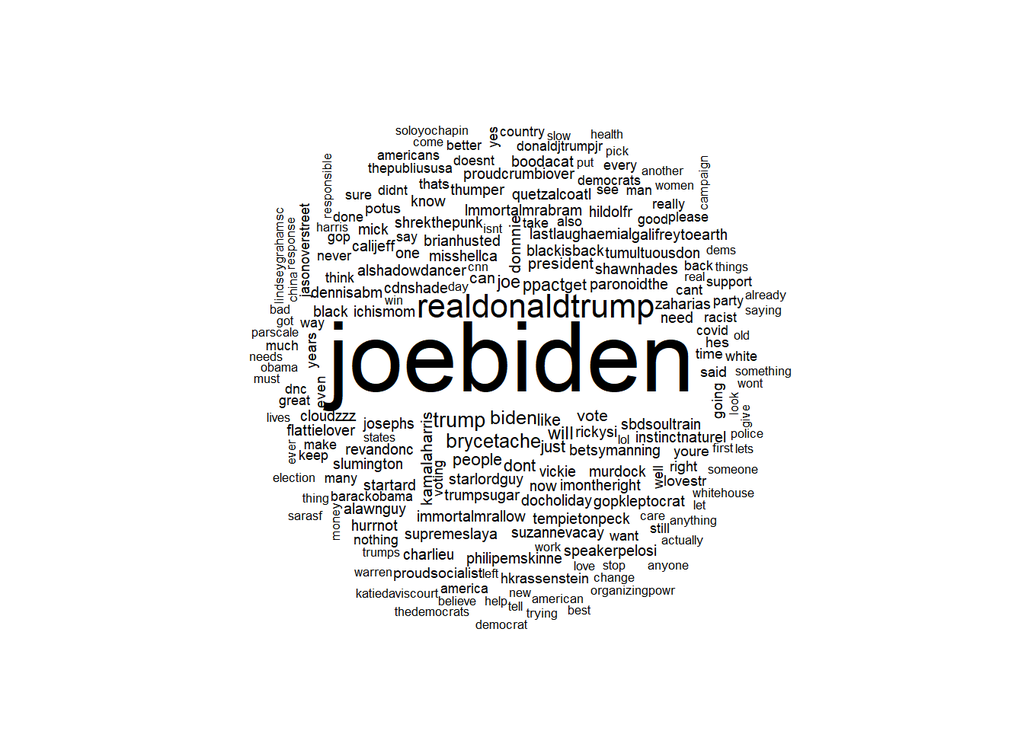

```r
wordcloud(corpus_cleanjb, min.freq = 150, random.order = FALSE)
```

### Seguidos

```r
jb_fds <- get_friends("JoeBiden")
jb_fds
```

```
## # A tibble: 26 x 2
##    user     user_id
##    <chr>    <chr>
##  1 JoeBiden 1141928541656952832
##  2 JoeBiden 1141929375639777280
##  3 JoeBiden 1141929016443777024
##  4 JoeBiden 1141928177046106114
##  5 JoeBiden 1129095209772552192
##  6 JoeBiden 609476852
##  7 JoeBiden 14230524
##  8 JoeBiden 2840712124
##  9 JoeBiden 821784477076750338
## 10 JoeBiden 869995492687716354
## # ... with 16 more rows
```

```r
jb_fds_data <- lookup_users(jb_fds$user_id)
jb_fds_data
```

```
## # A tibble: 26 x 90
##    user_id status_id created_at          screen_name text  source
##    <chr>   <chr>     <dttm>              <chr>       <chr> <chr>
##  1 114192~ 12317779~ 2020-02-24 03:08:36 JoeForNV    "Lov~ Twitt~
##  2 114192~ 12370354~ 2020-03-09 15:20:13 JoeForSC    "Oka~ Twitt~
##  3 114192~ 12721781~ 2020-06-14 14:44:43 JoeForNH    "Tom~ Twitt~
##  4 114192~ 12276704~ 2020-02-12 19:07:06 JoeForIA    "Tea~ Twitt~
##  5 112909~ 12733554~ 2020-06-17 20:43:00 TeamJoe     "Fro~ Tweet~
##  6 609476~ 12571058~ 2020-05-04 00:32:52 De11eDonne  "#Be~ Tweet~
##  7 142305~ 12729726~ 2020-06-16 19:21:45 ladygaga    "Sho~ Twitt~
##  8 284071~ 12733744~ 2020-06-17 21:58:20 ItsOnUs     "A s~ Twitt~
##  9 821784~ 12733608~ 2020-06-17 21:04:14 DrBiden     "Ema~ Twitt~
## 10 869995~ 12725987~ 2020-06-15 18:36:00 UDBidenInst "Lov~ Twitt~
## # ... with 16 more rows, and 84 more variables: display_text_width <int>,
## #   reply_to_status_id <chr>, reply_to_user_id <chr>,
## #   reply_to_screen_name <chr>, is_quote <lgl>, is_retweet <lgl>,
## #   favorite_count <int>, retweet_count <int>, quote_count <int>,
## #   reply_count <int>, hashtags <list>, symbols <list>, urls_url <list>,
## #   urls_t.co <list>, urls_expanded_url <list>, media_url <list>,
## #   media_t.co <list>, media_expanded_url <list>, media_type <list>,
## #   ext_media_url <list>, ext_media_t.co <list>, ext_media_expanded_url <list>,
## #   ext_media_type <chr>, mentions_user_id <list>, mentions_screen_name <list>,
## #   lang <chr>, quoted_status_id <chr>, quoted_text <chr>,
## #   quoted_created_at <dttm>, quoted_source <chr>, quoted_favorite_count <int>,
## #   quoted_retweet_count <int>, quoted_user_id <chr>, quoted_screen_name <chr>,
## #   quoted_name <chr>, quoted_followers_count <int>,
## #   quoted_friends_count <int>, quoted_statuses_count <int>,
## #   quoted_location <chr>, quoted_description <chr>, quoted_verified <lgl>,
## #   retweet_status_id <chr>, retweet_text <chr>, retweet_created_at <dttm>,
## #   retweet_source <chr>, retweet_favorite_count <int>,
## #   retweet_retweet_count <int>, retweet_user_id <chr>,
## #   retweet_screen_name <chr>, retweet_name <chr>,
## #   retweet_followers_count <int>, retweet_friends_count <int>,
## #   retweet_statuses_count <int>, retweet_location <chr>,
## #   retweet_description <chr>, retweet_verified <lgl>, place_url <chr>,
## #   place_name <chr>, place_full_name <chr>, place_type <chr>, country <chr>,
## #   country_code <chr>, geo_coords <list>, coords_coords <list>,
## #   bbox_coords <list>, status_url <chr>, name <chr>, location <chr>,
## #   description <chr>, url <chr>, protected <lgl>, followers_count <int>,
## #   friends_count <int>, listed_count <int>, statuses_count <int>,
## #   favourites_count <int>, account_created_at <dttm>, verified <lgl>,
## #   profile_url <chr>, profile_expanded_url <chr>, account_lang <lgl>,
## #   profile_banner_url <chr>, profile_background_url <chr>,
## #   profile_image_url <chr>
```

```r
jb_screen_name <- jb_fds_data[,4]
jb_screen_name
```

```
## # A tibble: 26 x 1
##    screen_name
##    <chr>
##  1 JoeForNV
##  2 JoeForSC
##  3 JoeForNH
##  4 JoeForIA
##  5 TeamJoe
##  6 De11eDonne
##  7 ladygaga
##  8 ItsOnUs
##  9 DrBiden
## 10 UDBidenInst
## # ... with 16 more rows
```

Tomo nota si Joe Biden sigue en la red social a su rival de campania.

```r
is.data.frame(jb_screen_name)
```

```
## [1] TRUE
```

```r
which(jb_screen_name$screen_name == "realDonaldTrump")
```

```
## integer(0)
```

Efectivamente no lo sigue, de lo contrario deberia de figurar el numero.

## Ver los tweets en gráfico

Instalamos la librería

```r
#install.packages("graphTweets") # CRAN release v0.4
#devtools::install_github("JohnCoene/graphTweets") # dev version
```

Vemos el gráfico

Uno pequeño ya que, tal como fue visto en clase, si es grande el grafico pierde sentido ya que no se logra divisar ninguna interaccion.

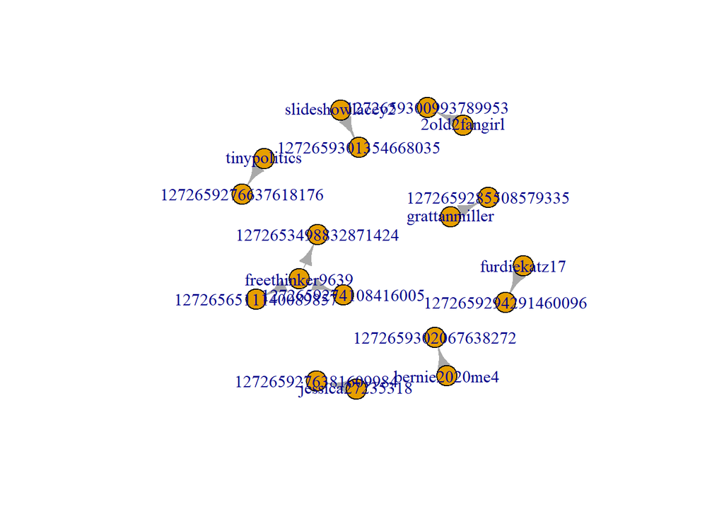

```r
jb_tweets[1:10, ] %>%
  gt_edges(screen_name, status_id) %>%
  gt_graph() %>%
  plot()
```

El grafico no ofrece mayor Información.

### Conclusión

Respecto al análisis de sentimiento, en ambos candidatos el orden es el mismo: Joy, Sadness, Anger, Fear, Surprise, Disgust. Sobre la polaridad, Donald Trump tiene mas twitts clasificados como negativos y menos positivos, respecto a Joe Biden. A destacar que la relación con “Floyd” en Biden menciona assassination, mientras que en Trump no. La palabra mas relacionada con campaign en el caso de Donald Trump es manager, belt, identity, revolved, mientras que en Joe Biden existing y tracked. Los candidatos no se siguen entre si en esta red social.